# 🛒 Superstore Sales & Profit Analysis- Exploratory Data Analysis (EDA)

## 📌 Project Overview

This project performs Exploratory Data Analysis (EDA) on a Superstore sales dataset to uncover business insights related to sales performance, profitability, customer segments, product categories, regional trends, and discount strategies.

The objective is to transform raw business data into actionable insights that can support better decision-making through data cleaning, visualization, and statistical analysis.

## 🎯 Project Objectives

- Understand the structure and quality of the dataset.
- Clean and prepare the data for analysis.
- Analyze sales and profit performance across categories, regions, and customer segments.
- Identify top-performing and underperforming products.
- Examine monthly sales and profit trends over time.
- Analyze the relationship between discounts and profitability.
- Generate actionable business insights and recommendations.

## 💼 Business Objective

The primary business objective of this analysis is to evaluate the sales and profitability performance of a retail superstore. Through exploratory data analysis, the project aims to identify high-performing products, profitable customer segments, regional sales patterns, seasonal trends, and the impact of discounts on profitability.

The insights generated from this analysis can help business stakeholders make data-driven decisions related to inventory management, pricing strategies, marketing campaigns, and overall business growth.

## 🛠️ Tools & Technologies Used

| Tool / Technology | Purpose |
| --- | --- |
| **Python** | Core programming language used for data analysis |
| **Pandas** | Data loading, cleaning, transformation, and analysis |
| **NumPy** | Numerical computations and mathematical operations |
| **Matplotlib** | Creating static data visualizations |
| **Seaborn** | Creating statistical and aesthetically enhanced visualizations |
| **Jupyter Notebook (VS Code)** | Interactive coding, analysis, and project documentation |

## 📂 Dataset

**Dataset Name:** SuperStoreOrders.csv

**File Format:** CSV

**Number of Records:** 51,290

**Number of Columns:** 21

### Dataset Description

The dataset contains transactional sales records of a retail superstore. Each record represents an individual customer order and includes customer information, product details, order and shipping dates, sales, quantity, discounts, profit, shipping cost, geographical information, and order priority.

This dataset is well suited for Exploratory Data Analysis (EDA) because it enables the analysis of sales performance, profitability, customer behavior, product performance, regional trends, shipping patterns, and time-based business trends.

# 📥 1. Import Libraries

## 🎯 Purpose

Before beginning the analysis, all required Python libraries are imported.

These libraries provide the tools needed for data manipulation, statistical analysis, visualization, and date formatting throughout the project. Importing them at the beginning keeps the notebook organized, avoids redundant code, and follows professional Python coding practices.

```python
# Data Manipulation
import pandas as pd
import numpy as np

# Data Visualization
import matplotlib.pyplot as plt
import matplotlib.dates as mdates
import seaborn as sns

# Formatting Utilities
from matplotlib.ticker import FuncFormatter
```

## 📚 Libraries Used

| **Library** | **Purpose** |
| --- | --- |
| **Pandas (`pandas`)** | Used for loading, cleaning, transforming, and analyzing tabular data. |
| **NumPy (`numpy`)** | Provides numerical computing functions and supports mathematical operations. |
| **Matplotlib (`matplotlib.pyplot`)** | Used to create charts and visualizations throughout the project. |
| **Matplotlib Dates (`matplotlib.dates`)** | Provides tools for formatting and displaying date-based axes in time-series visualizations. |
| **Seaborn (`seaborn`)** | Used to create statistical visualizations with enhanced aesthetics and simplified plotting functions. |
| **FuncFormatter (`matplotlib.ticker.FuncFormatter`)** | Formats chart axes with comma-separated numeric values, improving the readability of large numbers. |

## 💡 Why It Matters

Importing all required libraries at the beginning ensures that every subsequent analysis can access the necessary functions without repeatedly importing modules. This approach improves readability, reduces redundancy, and aligns with industry-standard Python development practices.

# 📂 2. Load the Dataset

## 🎯 Purpose

The dataset is loaded into a Pandas DataFrame, which serves as the primary data structure for analysis.

Loading the dataset is the first step in understanding the available data before performing cleaning, exploration, visualization, and business analysis.

```python
df = pd.read_csv("../data/SuperStoreOrders.csv")
```

## 🔎 Code Explanation

`df`

- The variable where the dataset is stored as a Pandas DataFrame.

`=`

- Assignment operator. It stores the loaded dataset into the variable `df`.

`pd.read_csv()`

- A Pandas function used to read data from a CSV (Comma-Separated Values) file.

`"../data/SuperStoreOrders.csv"`

- Specifies the relative path to the dataset.
- `..` means move one folder up from the current notebook location.
- `data/` is the folder containing the dataset.
- `SuperStoreOrders.csv` is the dataset file.

## 💡 Why It Matters

Loading the dataset correctly is the foundation of the entire analysis. Every cleaning step, visualization, statistical calculation, and business insight depends on successfully importing the dataset into a DataFrame.

```python
# Preview the first 5 rows
df.head()
```

|  | order_id | order_date | ship_date | ship_mode | customer_name | segment | state | country | market | region | ... | category | sub_category | product_name | sales | quantity | discount | profit | shipping_cost | order_priority | year |
| --- | --- | --- | --- | --- | --- | --- | --- | --- | --- | --- | --- | --- | --- | --- | --- | --- | --- | --- | --- | --- | --- |
| 0 | AG-2011-2040 | 1/1/2011 | 6/1/2011 | Standard Class | Toby Braunhardt | Consumer | Constantine | Algeria | Africa | Africa | ... | Office Supplies | Storage | Tenex Lockers, Blue | 408 | 2 | 0.0 | 106.140 | 35.46 | Medium | 2011 |
| 1 | IN-2011-47883 | 1/1/2011 | 8/1/2011 | Standard Class | Joseph Holt | Consumer | New South Wales | Australia | APAC | Oceania | ... | Office Supplies | Supplies | Acme Trimmer, High Speed | 120 | 3 | 0.1 | 36.036 | 9.72 | Medium | 2011 |
| 2 | HU-2011-1220 | 1/1/2011 | 5/1/2011 | Second Class | Annie Thurman | Consumer | Budapest | Hungary | EMEA | EMEA | ... | Office Supplies | Storage | Tenex Box, Single Width | 66 | 4 | 0.0 | 29.640 | 8.17 | High | 2011 |
| 3 | IT-2011-3647632 | 1/1/2011 | 5/1/2011 | Second Class | Eugene Moren | Home Office | Stockholm | Sweden | EU | North | ... | Office Supplies | Paper | Enermax Note Cards, Premium | 45 | 3 | 0.5 | -26.055 | 4.82 | High | 2011 |
| 4 | IN-2011-47883 | 1/1/2011 | 8/1/2011 | Standard Class | Joseph Holt | Consumer | New South Wales | Australia | APAC | Oceania | ... | Furniture | Furnishings | Eldon Light Bulb, Duo Pack | 114 | 5 | 0.1 | 37.770 | 4.70 | Medium | 2011 |

5 rows × 21 columns

### ✅ Section Summary

The Global Superstore dataset was successfully imported into the notebook and verified using a preview of the first five records. This confirms that the dataset has been loaded correctly and is ready for initial exploration.

# 🔍 3. Initial Data Exploration

## 🎯 Purpose

Before cleaning or analyzing the dataset, it is essential to understand its overall structure and quality.

Initial data exploration helps identify:

- The size of the dataset.
- Available columns.
- Data types.
- Missing values.
- Potential data quality issues.

Understanding the dataset at this stage ensures that the subsequent analysis is based on accurate and reliable information.

```python
# Check dataset dimensions
df.shape
```

```
(51290, 21)
```

```python
# Display all column names
df.columns.tolist()
```

```
['order_id',
 'order_date',
 'ship_date',
 'ship_mode',
 'customer_name',
 'segment',
 'state',
 'country',
 'market',
 'region',
 'product_id',
 'category',
 'sub_category',
 'product_name',
 'sales',
 'quantity',
 'discount',
 'profit',
 'shipping_cost',
 'order_priority',
 'year']
```

```python
# View data types and missing values
df.info()
```

```
<class 'pandas.core.frame.DataFrame'>
RangeIndex: 51290 entries, 0 to 51289
Data columns (total 21 columns):
 #   Column          Non-Null Count  Dtype
---  ------          --------------  -----
 0   order_id        51290 non-null  object
 1   order_date      51290 non-null  object
 2   ship_date       51290 non-null  object
 3   ship_mode       51290 non-null  object
 4   customer_name   51290 non-null  object
 5   segment         51290 non-null  object
 6   state           51290 non-null  object
 7   country         51290 non-null  object
 8   market          51290 non-null  object
 9   region          51290 non-null  object
 10  product_id      51290 non-null  object
 11  category        51290 non-null  object
 12  sub_category    51290 non-null  object
 13  product_name    51290 non-null  object
 14  sales           51290 non-null  object
 15  quantity        51290 non-null  int64
 16  discount        51290 non-null  float64
 17  profit          51290 non-null  float64
 18  shipping_cost   51290 non-null  float64
 19  order_priority  51290 non-null  object
 20  year            51290 non-null  int64
dtypes: float64(3), int64(2), object(16)
memory usage: 8.2+ MB
```

## 🔎 Code Explanation

The following commands were used to understand the overall structure and quality of the dataset before performing data cleaning and analysis.

### `df.shape`

- Returns the dimensions of the DataFrame as a tuple.
- The first value represents the number of rows (records).
- The second value represents the number of columns (features).

### `df.columns.tolist()`

- Returns all column names in the DataFrame.
- Converts the column index into a standard Python list for easier readability.
- Helps identify the available features for analysis.

### `df.info()`

- Displays a concise summary of the DataFrame.
- Provides information about:
  - Total number of rows and columns
  - Column names
  - Data types
  - Non-null values
  - Memory usage

This command is essential for understanding the dataset's structure before beginning the data cleaning process.

## 💡 Why It Matters

Initial data exploration provides a high-level understanding of the dataset before any modifications are made.

By examining the dataset dimensions, available columns, and data types, we can identify potential data quality issues, verify that the dataset has been loaded correctly, and determine the preprocessing steps required before conducting Exploratory Data Analysis (EDA).

This step forms the foundation for accurate and reliable business analysis.

## 🔎 Key Findings

Based on the initial exploration of the dataset:

- The dataset contains **51,290 records** and **21 columns**.
- No missing values were detected in any column.
- Most categorical variables are stored as the **object** data type.
- The **quantity** and **year** columns are stored as integer (`int64`) data types.
- The **discount**, **profit**, and **shipping_cost** columns are stored as floating-point (`float64`) data types.
- The **sales** column is currently stored as an **object** data type and will require conversion to a numeric data type.
- The **order_date** and **ship_date** columns are currently stored as **object** data types and will need to be converted to the **datetime** format during the data cleaning phase.

## ✅ Section Summary

✔️ Dataset dimensions verified.

✔️ Column names reviewed.

✔️ Data types inspected.

✔️ Missing values checked.

✔️ Initial data quality issues identified.

The dataset structure has now been fully understood and is ready for the data cleaning phase.

# 🧹 4. Data Cleaning

## 🎯 Purpose

Raw datasets often contain inconsistencies such as duplicate records, incorrect data types, or formatting issues that can affect the accuracy of the analysis.

The objective of this phase is to identify and resolve data quality issues so that the dataset is accurate, consistent, and ready for reliable exploratory data analysis.

The following data cleaning tasks will be performed:

- Check for duplicate records.
- Remove duplicate records (if present).
- Convert date columns to the appropriate datetime format.
- Convert numerical columns stored as text into numeric data types.
- Verify the updated data types after cleaning.

## Step 1: Check for Duplicate Records

### 🎯 Step Purpose

Before analyzing the dataset, it is important to check whether duplicate records exist.

Duplicate rows can lead to inaccurate calculations, biased results, and misleading business insights. Therefore, identifying and handling duplicate records is an essential part of the data cleaning process.

```python
df.duplicated().sum()
```

```
np.int64(0)
```

## 🔎 Code Explanation

`df.duplicated()`

- Compares each row with all previous rows to determine whether an identical record already exists.
- Returns a Boolean Series where:
  - `True` indicates a duplicate record.
  - `False` indicates a unique record.

`.sum()`

- Counts the total number of duplicate records by treating `True` as **1** and `False` as **0**.
- This provides the total number of duplicate rows present in the dataset.

The command `df.duplicated().sum()` is a quick and efficient way to identify whether duplicate records exist before performing any data cleaning.

## 💡 Why It Matters

Duplicate records can negatively impact data analysis by artificially increasing sales, profit, order counts, or other business metrics.

Identifying duplicate records before analysis helps ensure that the dataset accurately represents unique business transactions. This improves the reliability of the insights and supports better business decision-making.

## 📊 Findings

The duplicate record check returned **0**, indicating that the dataset does not contain any duplicate rows.

Since no duplicate records were identified, no rows needed to be removed, and the dataset can be used for further analysis without modification at this stage.

## ✅ Step Summary

- ✔️ Checked the dataset for duplicate records.
- ✔️ No duplicate records were found.
- ✔️ No rows were removed from the dataset.
- ✔️ The dataset is ready for the next data cleaning task.

## Step 2: Convert Date Columns

### 🎯 Purpose

The **order_date** and **ship_date** columns are currently stored as text (`object`) instead of a proper date format.

Converting these columns to the `datetime` data type enables accurate time-based analysis, such as monthly and yearly sales trends, shipping duration calculations, and other date-related business insights.

Since the dataset contains multiple date formats, appropriate conversion parameters are used to ensure all dates are interpreted correctly.

```python
df["order_date"] = pd.to_datetime(
    df["order_date"],
    format="mixed",
    dayfirst=True
)

df["ship_date"] = pd.to_datetime(
    df["ship_date"],
    format="mixed",
    dayfirst=True
)
```

```python
df[["order_date", "ship_date"]].dtypes
```

```
order_date    datetime64[ns]
ship_date     datetime64[ns]
dtype: object
```

## 🔎 Code Explanation

The `dtypes` attribute is used to display the data type of one or more columns in a DataFrame.

In this step, it is used to verify whether the **order_date** and **ship_date** columns have been successfully converted to the `datetime64[ns]` data type.

Verifying the data types after conversion is an important validation step that ensures the previous data cleaning operation was completed successfully.

## 💡 Why It Matters

Verifying data types is an essential part of the data cleaning process.

If date columns remain stored as text (`object`), time-based analyses such as monthly sales trends, yearly performance, shipping duration calculations, and seasonal analysis cannot be performed correctly.

Confirming that both columns are stored as `datetime64[ns]` ensures the dataset is ready for accurate time-series analysis.

## 📊 Key Findings

The verification confirms that both **order_date** and **ship_date** have been successfully converted to the **datetime64[ns]** data type.

The dataset contains multiple date formats (e.g., 1/1/2011 and 17-09-2012). Using format="mixed" with dayfirst=True ensures that all dates are interpreted correctly during conversion.

The date columns are now properly formatted and ready for further analysis.

## ✅ Step Summary

- ✔️ Converted **order_date** to datetime format.
- ✔️ Converted **ship_date** to datetime format.
- ✔️ Successfully handled mixed date formats.
- ✔️ Verified the updated data types.
- ✔️ The dataset is now ready for time-based analysis.

## Step 3: Convert Sales Column to Numeric

### 🎯 Step Purpose

The **sales** column represents the revenue generated from each transaction. Although it contains numerical values, it is currently stored as the **object** data type.

Before performing calculations such as total sales, average sales, profit analysis, and visualizations, the column must be converted into a numeric data type.

Converting the column ensures that mathematical operations can be performed accurately throughout the analysis.

```python
# Remove commas from the Sales values
df["sales"] = df["sales"].str.replace(",", "", regex=False)

# Convert the column to numeric
df["sales"] = pd.to_numeric(df["sales"])

# Verify the updated data type
df[["sales"]].dtypes
```

```
sales    int64
dtype: object
```

### 🔎 Code Explanation

The **sales** column was originally stored as the **object** data type because some values contained commas as thousands separators (for example, `1,648`).

To prepare the column for numerical analysis:

- The `str.replace()` method removes commas from each value, converting them into plain numeric strings.
- The `pd.to_numeric()` function converts the cleaned text values into the **int64** numeric data type.
- Finally, the `dtypes` attribute is used to verify that the conversion was successful.

This process ensures that the **sales** column can be used correctly in mathematical calculations, statistical analysis, and data visualizations.

## 💡 Why It Matters

Numerical analysis cannot be performed accurately when numeric values are stored as text.

Converting the **sales** column to a numeric data type enables calculations such as:

- Total Sales
- Average Sales
- Sales Distribution
- Correlation Analysis
- Business Performance Metrics
- Data Visualizations

This conversion ensures that all mathematical operations produce accurate and reliable results.

## 📈 Key Observations

The **sales** column was initially stored as the **object** data type due to the presence of commas in some values (for example, `1,648`).

After removing the commas and converting the column using `pd.to_numeric()`, the data type was successfully changed to **int64**.

The column is now fully prepared for numerical analysis and visualization.

## ✅ Step Summary

- ✔️ Identified formatting issues in the **sales** column.
- ✔️ Removed commas from sales values.
- ✔️ Converted the **sales** column to the **int64** data type.
- ✔️ Verified the updated data type.
- ✔️ The **sales** column is now ready for numerical analysis.

## Step 4: Verify Data Types

### 🎯 Step Purpose

After completing all data cleaning operations, it is important to verify that each column has the appropriate data type.

Correct data types are essential because they enable accurate calculations, proper date operations, meaningful statistical analysis, and reliable visualizations throughout the project.

This final verification confirms that the dataset is fully prepared for Exploratory Data Analysis (EDA).

```python
df.dtypes
```

```
order_id                  object
order_date        datetime64[ns]
ship_date         datetime64[ns]
ship_mode                 object
customer_name             object
segment                   object
state                     object
country                   object
market                    object
region                    object
product_id                object
category                  object
sub_category              object
product_name              object
sales                      int64
quantity                   int64
discount                 float64
profit                   float64
shipping_cost            float64
order_priority            object
year                       int64
dtype: object
```

## 🔎 Code Explanation

The `dtypes` attribute is used to display the data type of every column in the DataFrame.

After completing all data cleaning operations, this step verifies that important columns such as **order_date**, **ship_date**, and **sales** have been successfully converted to their appropriate data types.

This serves as the final validation before beginning Exploratory Data Analysis (EDA).

## 💡 Why It Matters

Verifying data types is a crucial quality assurance step in the data cleaning process.

Correct data types ensure that:

- Date columns support time-based analysis.
- Numeric columns allow mathematical calculations.
- Statistical analysis produces accurate results.
- Visualizations are generated correctly.

Without proper data types, business analysis may produce incorrect or misleading insights.

## 📈 Observations

The verification confirms that all major analytical columns now have the correct data types.

- **order_date** and **ship_date** are stored as `datetime64[ns]`.
- **sales** and **quantity** are stored as `int64`.
- **discount**, **profit**, and **shipping_cost** are stored as `float64`.

The dataset is now fully prepared for reliable exploratory data analysis.

## ✅ Step Summary

- ✔️ Verified the data types of all columns.
- ✔️ Confirmed successful date conversion.
- ✔️ Confirmed successful numeric conversion.
- ✔️ Validated the dataset for further analysis.
- ✔️ Data cleaning process successfully completed.

## 📋 Data Cleaning Checklist

| Cleaning Task | Status |
| --- | --- |
| Duplicate records checked | ✅ Completed |
| Duplicate records removed (if required) | ✅ Not Required |
| Date columns converted | ✅ Completed |
| Sales column converted to numeric | ✅ Completed |
| Data types verified | ✅ Completed |
| Dataset ready for analysis | ✅ Completed |

## 🏁 Data Cleaning Conclusion

All essential data cleaning tasks have been successfully completed.

The dataset was examined for duplicate records, inconsistent date formats, incorrect numerical formatting, and data type issues. Appropriate preprocessing techniques were applied to ensure the data is clean, consistent, and analysis-ready.

With the data cleaning phase complete, the dataset is now fully prepared for Exploratory Data Analysis (EDA), where meaningful business insights will be extracted through statistical analysis and data visualization.

# 📊 5. Exploratory Data Analysis (EDA)

## 🎯 Purpose

Exploratory Data Analysis (EDA) is the process of examining, summarizing, and visualizing data to uncover meaningful patterns, trends, relationships, and anomalies.

The objective of this section is to analyze the Superstore dataset from a business perspective by answering key business questions related to sales performance, profitability, customer behavior, product performance, regional trends, and operational efficiency.

The insights obtained from this analysis will support data-driven decision-making and help identify opportunities for improving overall business performance.

# 📌 5.1 Overall Business Performance (KPI Analysis)

## 📖 Business Scenario

Before analyzing individual business dimensions such as product categories, customer segments, and regions, it is important to understand the company's overall business performance.

Key Performance Indicators (KPIs) provide a high-level summary of the organization's financial performance and operational scale. These metrics help answer fundamental business questions, including:

- How much revenue has the company generated?
- How profitable is the business?
- How many customers have placed orders?
- What is the average value generated per transaction?

This section establishes the overall business context and serves as the foundation for all subsequent analyses in this notebook.

## 🎯 Business Questions

This analysis aims to answer the following business questions:

1. What is the company's total sales revenue?
2. What is the company's total profit?
3. How many unique orders have been placed?
4. How many unique customers have made purchases?
5. What is the average sales value per order?
6. What is the average profit earned per order?

## 🎯 Overall Step Purpose

The objective of this section is to calculate the key performance indicators (KPIs) that summarize the company's overall business performance.

These KPIs provide a concise overview of the organization's revenue, profitability, customer base, and order volume. Understanding these metrics establishes a benchmark against which all subsequent analyses can be interpreted.

## 📊 KPI Summary

The following table summarizes the six key performance indicators (KPIs) calculated from the Global Superstore dataset. These metrics provide a concise overview of the company's overall business performance and serve as the foundation for the detailed analyses presented in the subsequent sections.

```python
total_sales = df["sales"].sum()

total_profit = df["profit"].sum()

total_orders = df["order_id"].nunique()

total_customers = df["customer_name"].nunique()

average_sales = df["sales"].mean()

average_profit = df["profit"].mean()
```

```python
kpi_summary = pd.DataFrame({
    "KPI": [
        "Total Sales",
        "Total Profit",
        "Total Orders",
        "Total Customers",
        "Average Sales per Order",
        "Average Profit per Order"
    ],
    "Value": [
        df["sales"].sum(),
        df["profit"].sum(),
        df["order_id"].nunique(),
        df["customer_name"].nunique(),
        df["sales"].mean(),
        df["profit"].mean()
    ]
})

kpi_summary.style.hide(axis="index").format({
    "Value": lambda x: f"{x:,.2f}" if isinstance(x, float) else f"{x:,}"
})
```

| KPI | Value |
| --- | --- |
| Total Sales | 12,642,905.00 |
| Total Profit | 1,469,034.82 |
| Total Orders | 25,035.00 |
| Total Customers | 795.00 |
| Average Sales per Order | 246.50 |
| Average Profit per Order | 28.64 |

## 📝 KPI Interpretation

The KPI summary presents a consolidated overview of the company's overall business performance.

It highlights the organization's revenue, profitability, customer base, and order activity, providing a baseline for evaluating the detailed analyses presented in the subsequent sections of this notebook.

These metrics help quantify the overall scale of the business before examining individual categories, customer segments, markets, and regions.

## 📌 Executive Snapshot

### Key Highlights

These KPIs establish the baseline for the detailed analyses that follow, including product category performance, customer segments, regional trends, market analysis, and profitability drivers.

## 🔎 Code Explanation

This code calculates six important Key Performance Indicators (KPIs) using built-in Pandas aggregation functions.

## 💡 Why It Matters

Key Performance Indicators (KPIs) provide a quick summary of the overall health of a business.

Before analyzing specific business dimensions, decision-makers need to understand the organization's overall performance. These metrics serve as benchmark values that help compare the contribution of different product categories, customer segments, markets, and regions throughout the remainder of the analysis.

## 🧠 Business Insights

The KPI summary indicates that the Superstore operates at a substantial business scale, generating strong overall revenue while maintaining positive profitability.

Although the business is profitable overall, the average profit earned per order is relatively modest compared to the average sales value. This suggests that profitability may vary significantly across different products, customer segments, and regions.

The following analyses will investigate these business dimensions to identify the primary drivers of revenue and profit, as well as areas where operational improvements can be made.

## 💼 Business Recommendation

Management should continue monitoring these KPIs as primary performance indicators while investigating the factors that influence profitability across different business dimensions.

Future business strategies should focus on increasing average profit per order through optimized pricing, product mix, inventory management, and targeted marketing initiatives.

## ⭐ Key Takeaway

The Superstore generated strong overall revenue and remained profitable, providing a solid foundation for deeper business performance analysis.

## ✅ Section Summary (5.1)

This section evaluated the Superstore's overall business performance using six key performance indicators (KPIs), providing a comprehensive overview of the company's revenue, profitability, customer base, and order activity.

The analysis established the overall business baseline and confirmed that the company operated profitably during the analysis period. These benchmark metrics will serve as reference points for interpreting the detailed analyses of product categories, customer segments, regional performance, markets, and other business dimensions presented in the following sections.

## 📌 Next Analysis

The KPI analysis provided a high-level overview of the company's overall business performance by establishing key benchmark metrics for sales, profitability, customer activity, and order volume.

To better understand the factors driving these overall results, the next section examines business performance across different product categories. This analysis will identify the categories that contribute most significantly to revenue and profit, helping management recognize both the company's strongest-performing products and areas with opportunities for improvement.

## 📊 5.2 Category Analysis

## 📖 Business Scenario

Product categories play a critical role in determining a company's overall business performance. Each category contributes differently to revenue generation and profitability, making it essential to evaluate their individual performance.

Understanding how each category performs enables management to identify the organization's strongest revenue drivers, recognize underperforming areas, and make informed decisions regarding inventory planning, pricing strategies, marketing investments, and resource allocation.

This analysis focuses on comparing the sales and profit generated by each product category to uncover meaningful business insights.

## 🎯 Business Questions

This analysis aims to answer the following business questions:

1. Which product category generates the highest sales?
2. Which product category contributes the highest profit?
3. Do higher sales always result in higher profitability?
4. Which product category demonstrates the strongest overall business performance?
5. Which category requires greater managerial attention to improve profitability?

## 🎯 Overall Step Purpose

The objective of this section is to evaluate the business performance of each product category using two key performance metrics: Total Sales and Total Profit.

The analysis begins with a high-level comparison of category performance through a summary table, followed by separate visual analyses of sales and profitability. This approach helps identify the categories that contribute most significantly to the company's revenue and profit while highlighting areas that may require strategic improvement.

## 📋 Category Performance Summary

The following table summarizes the overall performance of each product category based on two key business metrics: **Total Sales** and **Total Profit**.

This high-level comparison provides an overview of how each category contributes to the company's revenue and profitability before examining sales and profit individually through visual analysis.

```python
category_summary = (
    df.groupby("category")
      .agg(
          Total_Sales=("sales", "sum"),
          Total_Profit=("profit", "sum")
      )
      .round(2)
)
```

```python
category_summary.style.format({
    "Total_Sales": "{:,.0f}",
    "Total_Profit": "{:,.2f}"
})
```

| category | Total_Sales | Total_Profit |
| --- | --- | --- |
| Furniture | 4,110,884 | 286,782.25 |
| Office Supplies | 3,787,330 | 518,473.83 |
| Technology | 4,744,691 | 663,778.73 |

## 📝 Summary Table Interpretation

The summary table reveals noticeable differences in the business performance of the three product categories.

Technology generated the highest sales as well as the highest profit, indicating strong overall performance. Furniture also contributed substantially to total sales but produced comparatively lower profit, suggesting relatively lower profit margins. Office Supplies generated the lowest sales among the three categories while maintaining healthy profitability.

These findings provide an initial understanding of category performance and will be explored further through separate analyses of sales and profit.

## 📊 5.2.1 Sales Analysis by Category

## 🎯 Step Purpose

The objective of this analysis is to compare the total sales generated by each product category.

By visualizing category-wise sales, we can identify the primary revenue drivers of the business and understand how sales are distributed across different product categories.

## 📊 Chart Introduction

The following bar chart illustrates the total sales generated by each product category.

Visualizing the sales distribution makes it easier to compare category performance and quickly identify which categories contribute the most to the company's overall revenue.

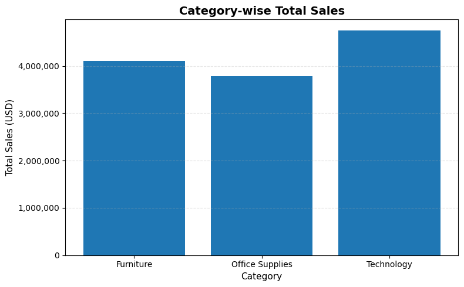

```python
plt.figure(figsize=(8,5))

plt.bar(
    category_summary.index,
    category_summary["Total_Sales"]
)

plt.title("Category-wise Total Sales", fontsize=14, fontweight="bold")

plt.xlabel("Category", fontsize=11)

plt.ylabel("Total Sales (USD)", fontsize=11)

plt.grid(axis="y", linestyle="--", alpha=0.3)

plt.gca().yaxis.set_major_formatter(
    FuncFormatter(lambda x, pos: f'{x:,.0f}')
)

plt.tight_layout()

plt.show()
```

## 🔎 Code Explanation

This visualization is created using Matplotlib's `bar()` function to compare the total sales generated by each product category.

The chart uses the precomputed `category_summary` table, where:

- The x-axis represents the product categories.
- The y-axis represents the total sales generated by each category.

Additional formatting such as chart title, axis labels, gridlines, and comma-separated number formatting improves readability and makes the visualization suitable for business reporting.

## 💡 Why It Matters

Sales performance indicates how much revenue each product category contributes to the business.

Comparing category-wise sales helps management identify the organization's primary revenue sources, evaluate product demand, and prioritize future investments in inventory, marketing, and product development.

## 📈 Key Observations

- Technology generated the highest total sales among all product categories.
- Furniture recorded the second-highest sales performance.
- Office Supplies generated the lowest total sales.
- Although the differences are not extremely large, Technology clearly outperformed the other two categories in terms of revenue generation.

## 🧠 Business Insights

The Technology category serves as the company's strongest revenue driver, indicating high customer demand and strong market performance.

Furniture also contributes significantly to overall revenue, while Office Supplies generates comparatively lower sales. However, high sales alone do not necessarily imply higher profitability. Therefore, the next analysis examines category-wise profit to determine whether revenue generation translates into financial performance.

## 💼 Business Recommendation

Management should continue strengthening the Technology category through strategic marketing, product expansion, and inventory optimization to sustain its revenue leadership.

At the same time, further investigation should be conducted to understand the factors limiting sales growth in the Office Supplies category and identify opportunities for improvement.

## ⭐ Key Takeaway

Technology is the highest revenue-generating product category and serves as the primary sales driver of the business.

## ✅ Step Summary

This analysis compared the total sales generated by each product category and identified Technology as the leading contributor to overall revenue. The findings provide valuable insight into the company's sales distribution and establish the foundation for evaluating whether high sales also translate into high profitability in the next analysis.

## 📊 5.2.2 Profit Analysis by Category

## 🎯 Step Purpose

The objective of this analysis is to compare the total profit generated by each product category.

While sales indicate revenue generation, profit provides a clearer measure of financial performance. This analysis helps identify which product categories contribute most effectively to the company's profitability.

## 📊 Chart Introduction

The following bar chart illustrates the total profit earned by each product category.

By comparing category-wise profit, we can determine which categories generate the greatest financial returns and assess whether high sales are accompanied by strong profitability.

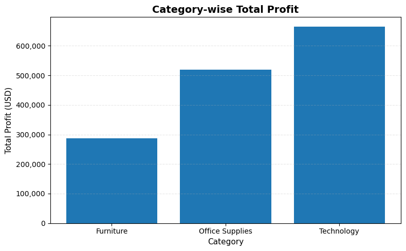

```python
plt.figure(figsize=(8,5))

plt.bar(
    category_summary.index,
    category_summary["Total_Profit"]
)

plt.title(
    "Category-wise Total Profit",
    fontsize=14,
    fontweight="bold"
)

plt.xlabel("Category", fontsize=11)

plt.ylabel("Total Profit (USD)", fontsize=11)

plt.grid(axis="y", linestyle="--", alpha=0.3)

plt.gca().yaxis.set_major_formatter(
    FuncFormatter(lambda x, pos: f"{x:,.0f}")
)

plt.tight_layout()

plt.show()
```

## 🔎 Code Explanation

This visualization is created using Matplotlib's `bar()` function to compare the total profit generated by each product category.

The chart is based on the precomputed `category_summary` table, where:

- The x-axis represents the product categories.
- The y-axis represents the total profit earned by each category.

Formatting elements such as descriptive axis labels, comma-separated number formatting, gridlines, and a clear chart title improve readability and make the visualization suitable for business reporting.

## 💡 Why It Matters

Profitability is a key indicator of business success because it reflects the company's ability to generate financial returns from its operations.

Comparing profit across product categories helps identify the areas that create the greatest business value, supports strategic decision-making, and enables management to allocate resources more effectively.

## 📈 Key Observations

- Technology generated the highest total profit among all product categories.
- Office Supplies ranked second in terms of total profit.
- Furniture generated the lowest total profit.
- Furniture produced lower profit than Office Supplies despite generating higher total sales.

## 💼 Business Recommendation

Management should continue strengthening the Technology category through product expansion, targeted marketing initiatives, and efficient inventory management to sustain its strong financial performance.

For the Furniture category, a detailed profitability analysis should be conducted to identify the factors reducing profit margins. Reviewing pricing strategies, discount policies, procurement costs, and operational expenses may help improve profitability while maintaining sales performance.

## ⭐ Key Takeaway

Technology is the strongest-performing product category, while Furniture presents the greatest opportunity for improving profitability.

## ✅ Analysis Summary

This analysis compared the total profit generated by each product category and identified Technology as the company's most profitable category. It also revealed that strong sales performance does not always result in high profitability, emphasizing the importance of evaluating both revenue and profit when assessing business performance.

## ✅ Section Summary (5.2)

This section evaluated the performance of the company's product categories using **Total Sales** and **Total Profit** as the primary business metrics.

The analysis identified **Technology** as the strongest-performing category, leading in both revenue and profitability. It also revealed that high sales do not always translate into high profit, as the **Furniture** category generated substantial sales but comparatively lower profit than **Office Supplies**.

These findings highlight the importance of evaluating both sales and profitability when assessing product performance and provide valuable insights for product portfolio management, pricing strategies, and future business planning.

## ➡️ Next Analysis

The category analysis identified the products that contribute most significantly to the company's sales and profitability. However, business performance is influenced not only by the products being sold but also by the customers purchasing them.

The next section shifts the focus from **products** to **customers** by examining the performance of different customer segments. This analysis will help determine which customer groups generate the greatest business value and provide insights for developing more targeted marketing and sales strategies.

## 📊 5.3 Customer Segment Analysis

## 📖 Business Scenario

Customers are one of the most valuable assets of any business. However, not all customer groups contribute equally to revenue and profitability. Understanding the purchasing behavior and financial contribution of different customer segments enables organizations to develop targeted marketing strategies, improve customer relationships, and allocate resources more effectively.

The Global Superstore categorizes its customers into three segments: **Consumer**, **Corporate**, and **Home Office**. Analyzing the performance of these segments helps identify the most valuable customer groups and supports data-driven business decisions aimed at maximizing long-term profitability.

## 🎯 Business Questions

This analysis aims to answer the following business questions:

1. Which customer segment generates the highest sales?
2. Which customer segment contributes the highest profit?
3. Does the most profitable segment also generate the highest sales?
4. Which customer segment creates the greatest overall business value?
5. Which customer segment offers opportunities for future business growth?

## 🎯 Overall Step Purpose

The objective of this section is to evaluate the performance of different customer segments using two key business metrics: **Total Sales** and **Total Profit**.

The analysis begins with a summary comparison of all customer segments, followed by separate visual analyses of sales and profitability. This approach helps identify the customer groups that contribute most significantly to the company's financial performance and supports the development of effective customer-focused business strategies.

## 📋 Customer Segment Performance Summary

The following table summarizes the overall performance of each customer segment based on two key business metrics: **Total Sales** and **Total Profit**.

This high-level comparison provides an overview of how each customer segment contributes to the company's revenue and profitability before examining sales and profit individually through visual analysis.

```python
segment_summary = (
    df.groupby("segment")
      .agg(
          Total_Sales=("sales", "sum"),
          Total_Profit=("profit", "sum")
      )
      .round(2)
)

segment_summary.style.format({
    "Total_Sales": "{:,.0f}",
    "Total_Profit": "{:,.2f}"
})
```

| segment | Total_Sales | Total_Profit |
| --- | --- | --- |
| Consumer | 6,508,141 | 749,239.78 |
| Corporate | 3,824,808 | 442,785.86 |
| Home Office | 2,309,956 | 277,009.18 |

## 📝 Summary Table Interpretation

The summary table indicates clear differences in the financial performance of the three customer segments.

The **Consumer** segment generated the highest sales and the highest profit, making it the company's strongest-performing customer group. The **Corporate** segment ranked second in both sales and profitability, while the **Home Office** segment contributed the lowest sales and profit.

These findings provide an overall understanding of customer segment performance and establish the foundation for the detailed sales and profit analyses presented in the following subsections.

## 📊 5.3.1 Sales Analysis by Customer Segment

## 🎯 Step Purpose

The objective of this analysis is to compare the total sales generated by each customer segment.

By visualizing segment-wise sales, we can identify the customer groups that contribute the most to the company's revenue and better understand the distribution of sales across different customer segments.

## 📊 Chart Introduction

The following bar chart illustrates the total sales generated by each customer segment.

Visualizing the sales distribution enables an easy comparison of customer segment performance and helps identify the organization's primary revenue-generating customer groups.

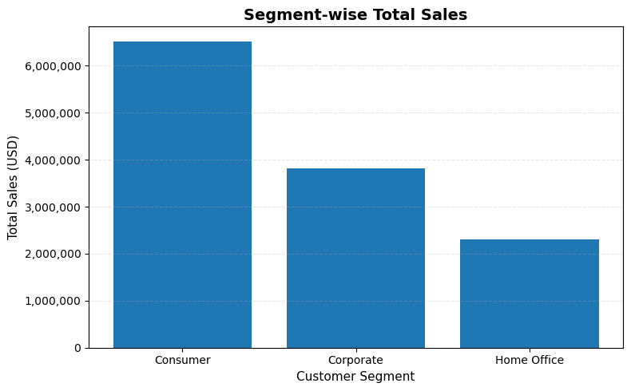

```python
plt.figure(figsize=(8,5))

plt.bar(
    segment_summary.index,
    segment_summary["Total_Sales"]
)

plt.title(
    "Segment-wise Total Sales",
    fontsize=14,
    fontweight="bold"
)

plt.xlabel("Customer Segment", fontsize=11)

plt.ylabel("Total Sales (USD)", fontsize=11)

plt.grid(axis="y", linestyle="--", alpha=0.3)

plt.gca().yaxis.set_major_formatter(
    FuncFormatter(lambda x, pos: f"{x:,.0f}")
)

plt.tight_layout()

plt.show()
```

## 🔎 Code Explanation

This visualization is created using Matplotlib's `bar()` function to compare the total sales generated by each customer segment.

The chart is based on the precomputed `segment_summary` table, where:

- The x-axis represents the customer segments.
- The y-axis represents the total sales generated by each segment.

Additional formatting, including descriptive axis labels, comma-separated number formatting, gridlines, and a clear chart title, enhances readability and makes the visualization suitable for business reporting.

## 💡 Why It Matters

Customer segments contribute differently to business revenue. Understanding their sales performance helps management identify the organization's most valuable customer groups and develop targeted marketing, sales, and customer retention strategies.

Segment-wise sales analysis also supports better resource allocation by highlighting where future business growth opportunities are most likely to exist.

## 📈 Key Observations

- The Consumer segment generated the highest total sales among all customer segments.
- The Corporate segment ranked second in terms of total sales.
- The Home Office segment generated the lowest total sales.
- The Consumer segment contributed substantially more revenue than both the Corporate and Home Office segments.

## 🧠 Business Insights

The Consumer segment is the company's primary revenue-generating customer group, indicating strong customer demand and a broad purchasing base within this segment.

Although the Corporate and Home Office segments contribute a smaller share of total sales, they may represent opportunities for targeted business expansion. Understanding their purchasing behavior could help the company design more effective marketing campaigns and customer engagement strategies.

## 💼 Business Recommendation

Management should continue strengthening the Consumer segment through customer loyalty programs, personalized promotions, and improved customer experience to maintain its strong revenue contribution.

For the Corporate and Home Office segments, targeted marketing initiatives and customized product offerings should be explored to increase customer acquisition and encourage higher purchasing activity.

## ⭐ Key Takeaway

The Consumer segment is the company's largest revenue-generating customer segment and represents its strongest source of sales.

## ✅ Step Summary

This analysis compared the total sales generated by each customer segment and identified the Consumer segment as the company's primary revenue contributor. The findings provide valuable insight into customer purchasing patterns and establish the foundation for evaluating whether the highest-selling segment also delivers the greatest profitability.

## 📊 5.3.2 Profit Analysis by Customer Segment

## 🎯 Step Purpose

The objective of this analysis is to compare the total profit generated by each customer segment.

While sales measure revenue generation, profit reflects the actual financial value contributed by each customer segment. This analysis helps identify the customer groups that contribute most effectively to the company's overall profitability.

## 📊 Chart Introduction

The following bar chart illustrates the total profit generated by each customer segment.

By comparing segment-wise profit, we can identify the customer groups that create the greatest financial value and evaluate whether the highest-selling segments also generate the highest profitability.

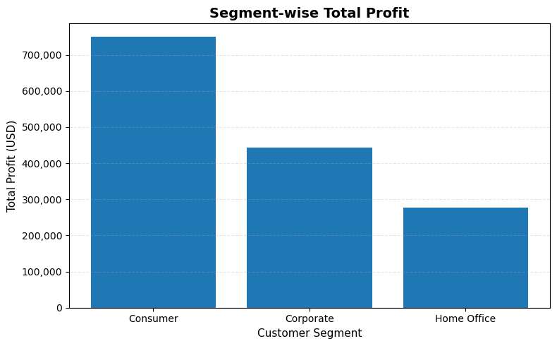

```python
plt.figure(figsize=(8,5))

plt.bar(
    segment_summary.index,
    segment_summary["Total_Profit"]
)

plt.title(
    "Segment-wise Total Profit",
    fontsize=14,
    fontweight="bold"
)

plt.xlabel("Customer Segment", fontsize=11)

plt.ylabel("Total Profit (USD)", fontsize=11)

plt.grid(axis="y", linestyle="--", alpha=0.3)

plt.gca().yaxis.set_major_formatter(
    FuncFormatter(lambda x, pos: f"{x:,.0f}")
)

plt.tight_layout()

plt.show()
```

## 🔎 Code Explanation

This visualization is created using Matplotlib's `bar()` function to compare the total profit generated by each customer segment.

The chart is based on the precomputed `segment_summary` table, where:

- The x-axis represents the customer segments.
- The y-axis represents the total profit generated by each segment.

Additional formatting, including descriptive axis labels, comma-separated number formatting, gridlines, and a clear chart title, enhances readability and makes the visualization suitable for business reporting.

## 💡 Why It Matters

Profitability is a key indicator of customer value because it reflects the financial return generated by each customer segment.

Analyzing segment-wise profit helps management identify the customer groups that contribute most effectively to business growth and supports informed decisions related to customer acquisition, retention, and resource allocation.

## 📈 Key Observations

- The Consumer segment generated the highest total profit among all customer segments.
- The Corporate segment ranked second in terms of total profit.
- The Home Office segment generated the lowest total profit.
- The ranking of customer segments remained consistent across both sales and profit.

## 🧠 Business Insights

The Consumer segment is the company's most valuable customer group, contributing the highest revenue as well as the highest profit. This indicates that the segment not only purchases frequently but also creates strong financial value for the business.

The Corporate segment demonstrates solid business potential and may offer opportunities for further growth through targeted relationship management and customized business solutions. Although the Home Office segment contributes the least to overall profitability, it may still represent a niche market with potential for expansion through specialized marketing strategies.

## 💼 Business Recommendation

Management should continue strengthening customer engagement within the Consumer segment through loyalty programs, personalized marketing, and enhanced customer experience initiatives.

For the Corporate and Home Office segments, focused marketing campaigns, tailored product offerings, and customer relationship strategies should be explored to increase profitability and expand their contribution to overall business performance.

## ⭐ Key Takeaway

The Consumer segment is the company's most profitable customer segment and represents its highest overall business value.

## ✅ Analysis Summary

This analysis compared the total profit generated by each customer segment and identified the Consumer segment as the company's strongest contributor to profitability. The results demonstrate that the segment leading in sales also leads in profit, confirming its importance to the organization's overall financial performance.

## ✅ Section Summary (5.3)

This section evaluated the performance of the company's customer segments using total sales and total profit as key performance indicators. The analysis identified the Consumer segment as the strongest-performing customer group, contributing the highest revenue as well as the highest profit.

These findings highlight the importance of understanding customer segment performance when developing marketing strategies, strengthening customer relationships, and allocating business resources effectively.

## ➡️ Next Analysis

The customer segment analysis identified the groups that contribute most significantly to the company's sales and profitability. However, customer performance can also vary across different geographical locations.

The next section shifts the focus from **customer segments** to **regions** by examining regional sales and profit performance. This analysis will help identify the company's strongest geographic markets and highlight regions that offer opportunities for future business growth.

# 📊 5.4 Regional Analysis

## 📖 Business Scenario

Geographical performance plays a critical role in business decision-making. Sales and profitability often vary across regions due to differences in customer demand, market size, competition, economic conditions, and operational efficiency.

By analyzing regional performance, organizations can identify their strongest markets, recognize underperforming regions, and make informed decisions regarding resource allocation, market expansion, and regional business strategies.

This analysis evaluates the performance of each region using **Total Sales** and **Total Profit** to determine how different geographical areas contribute to the company's overall business performance.

## 🎯 Business Questions

This analysis aims to answer the following business questions:

1. Which region generates the highest sales?
2. Which region contributes the highest profit?
3. Are high-sales regions also the most profitable?
4. Which regions require greater business attention and improvement?
5. How can regional performance support future business expansion strategies?

## 🎯 Overall Step Purpose

The objective of this section is to evaluate the performance of different geographical regions using **Total Sales** and **Total Profit**.

The analysis begins with a summary comparison of regional performance, followed by separate visual analyses of sales and profitability. The findings will help identify the company's strongest geographical markets and support data-driven decisions related to regional growth and business planning.

## 📋 Regional Performance Summary

The following table summarizes the performance of each geographical region using **Total Sales** and **Total Profit**.

This high-level comparison provides an overview of how different regions contribute to the company's overall revenue and profitability before examining sales and profit individually through visual analysis.

```python
region_summary = (
    df.groupby("region")
      .agg(
          Total_Sales=("sales", "sum"),
          Total_Profit=("profit", "sum")
      )
      .round(2)
)

region_summary.style.format({
    "Total_Sales": "{:,.0f}",
    "Total_Profit": "{:,.2f}"
})
```

| region | Total_Sales | Total_Profit |
| --- | --- | --- |
| Africa | 783,776 | 88,871.63 |
| Canada | 66,932 | 17,817.39 |
| Caribbean | 324,281 | 34,571.32 |
| Central | 2,822,399 | 311,403.98 |
| Central Asia | 752,839 | 132,480.19 |
| EMEA | 806,184 | 43,897.97 |
| East | 678,834 | 91,522.78 |
| North | 1,248,192 | 194,597.95 |
| North Asia | 848,349 | 165,578.42 |
| Oceania | 1,100,207 | 121,666.64 |
| South | 1,600,960 | 140,355.77 |
| Southeast Asia | 884,438 | 17,852.33 |
| West | 725,514 | 108,418.45 |

## 📝 Summary Table Interpretation

The summary table shows noticeable differences in business performance across the company's geographical regions.

The **Central** region generated the highest sales as well as the highest profit, making it the company's strongest-performing region. In contrast, some regions with relatively high sales, such as **South** and **Southeast Asia**, generated comparatively lower profit, indicating that higher revenue does not always result in greater profitability.

These findings provide an overall understanding of regional performance and establish the foundation for the detailed sales and profit analyses presented in the following subsections.

## 📊 5.4.1 Sales Analysis by Region

## 🎯 Step Purpose

The objective of this analysis is to compare the total sales generated across different geographical regions.

By visualizing regional sales performance, we can identify the company's strongest revenue-generating markets and better understand the distribution of sales across different geographical areas.

## 📊 Chart Introduction

The following bar chart illustrates the total sales generated by each geographical region.

Visualizing regional sales performance enables an easy comparison of business activity across markets and helps identify the regions that contribute most significantly to the company's overall revenue.

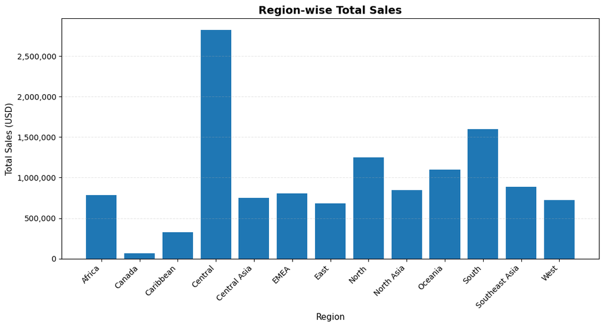

```python
plt.figure(figsize=(11,6))

plt.bar(
    region_summary.index,
    region_summary["Total_Sales"]
)

plt.title(
    "Region-wise Total Sales",
    fontsize=14,
    fontweight="bold"
)

plt.xlabel("Region", fontsize=11)

plt.ylabel("Total Sales (USD)", fontsize=11)

plt.xticks(rotation=45, ha="right")

plt.grid(axis="y", linestyle="--", alpha=0.3)

plt.gca().yaxis.set_major_formatter(
    FuncFormatter(lambda x, pos: f"{x:,.0f}")
)

plt.tight_layout()

plt.show()
```

## 🔎 Code Explanation

This visualization is created using Matplotlib's `bar()` function to compare the total sales generated by each geographical region.

The chart is based on the precomputed `region_summary` table, where:

- The x-axis represents the geographical regions.
- The y-axis represents the total sales generated by each region.

Additional formatting, including descriptive axis labels, rotated region names, comma-separated number formatting, gridlines, and a clear chart title, enhances readability and makes the visualization suitable for business reporting.

## 💡 Why It Matters

Regional sales analysis helps organizations understand which geographical markets contribute most significantly to overall revenue. Identifying high-performing and low-performing regions enables management to allocate resources more effectively, strengthen successful markets, and develop improvement strategies for underperforming regions.

Understanding regional sales performance also supports business expansion, market prioritization, and strategic decision-making.

## 📈 Key Observations

- The Central region generated the highest total sales among all regions.
- The South region ranked second in terms of total sales.
- The North region recorded the third-highest sales.
- Canada generated the lowest total sales.
- Considerable variation exists in sales performance across different geographical regions.

## 🧠 Business Insights

The Central region represents the company's strongest revenue-generating market, indicating high customer demand and strong business presence in this region.

The substantial differences in regional sales suggest that market potential varies considerably across geographical locations. Regions with relatively lower sales may require targeted marketing efforts, improved distribution strategies, or deeper market analysis to identify opportunities for growth.

## 💼 Business Recommendation

Management should continue investing in high-performing regions such as Central and South to sustain their strong sales performance while identifying the key success factors that can be replicated in other regions.

For lower-performing regions, particularly Canada and the Caribbean, management should investigate potential market barriers and consider targeted promotional campaigns, customer acquisition strategies, or operational improvements to stimulate sales growth.

## ⭐ Key Takeaway

The Central region is the company's largest revenue-generating market, while significant differences in regional sales indicate opportunities for targeted market development.

## ✅ Analysis Summary

This analysis compared total sales across geographical regions and identified the Central region as the company's strongest revenue contributor. The results highlight considerable variation in regional sales performance and provide valuable insights for market prioritization and regional business strategy.

## 📊 5.4.2 Profit Analysis by Region

## 🎯 Step Purpose

The objective of this analysis is to compare the total profit generated across different geographical regions.

While sales indicate revenue generation, profit reflects the actual financial contribution of each region. This analysis helps identify the regions that create the greatest business value and supports strategic decisions for regional business growth.

## 📊 Chart Introduction

The following bar chart illustrates the total profit generated by each geographical region.

By comparing regional profitability, we can identify the company's most valuable markets and determine whether the regions with the highest sales also contribute the highest profit.

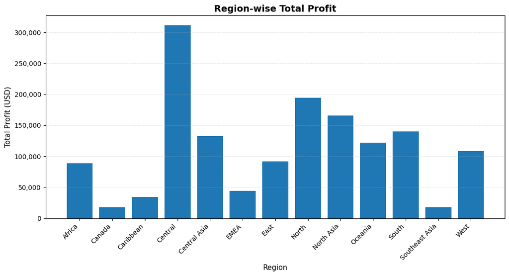

```python
plt.figure(figsize=(11,6))

plt.bar(
    region_summary.index,
    region_summary["Total_Profit"]
)

plt.title(
    "Region-wise Total Profit",
    fontsize=14,
    fontweight="bold"
)

plt.xlabel("Region", fontsize=11)

plt.ylabel("Total Profit (USD)", fontsize=11)

plt.xticks(rotation=45, ha="right")

plt.grid(axis="y", linestyle="--", alpha=0.3)

plt.gca().yaxis.set_major_formatter(
    FuncFormatter(lambda x, pos: f"{x:,.0f}")
)

plt.tight_layout()

plt.show()
```

## 🔎 Code Explanation

This visualization is created using Matplotlib's `bar()` function to compare the total profit generated by each geographical region.

The chart is based on the precomputed `region_summary` table, where:

- The x-axis represents the geographical regions.
- The y-axis represents the total profit generated by each region.

Additional formatting, including descriptive axis labels, rotated region names, comma-separated number formatting, gridlines, and a clear chart title, improves readability and makes the visualization suitable for business reporting.

## 💡 Why It Matters

Profitability is a more meaningful indicator of business success than sales alone because it reflects the actual financial value generated after business operations.

Regional profit analysis helps management identify the most profitable markets, evaluate the effectiveness of regional business strategies, and prioritize investments in areas that generate the greatest financial return.

## 📈 Key Observations

- The Central region generated the highest total profit among all regions.
- The North region recorded the second-highest total profit.
- North Asia ranked third in terms of profitability.
- Canada and Southeast Asia generated the lowest total profits.
- Regional profitability varies considerably across different geographical markets.

## 🧠 Business Insights

The Central region not only generated the highest sales but also achieved the highest profit, indicating strong overall business performance.

Although the South region ranked second in sales, it generated lower profit than both North and North Asia, suggesting comparatively lower profit margins. Similarly, Southeast Asia produced moderate sales but very low profit, indicating potential pricing, discount, or cost-related challenges that may require further investigation.

## 💼 Business Recommendation

Management should continue strengthening operations in highly profitable regions such as Central, North, and North Asia while identifying the factors driving their strong financial performance.

For regions such as South and Southeast Asia, where profitability is relatively low compared to sales, management should evaluate pricing strategies, discount policies, product mix, and operational costs to improve profit margins.

## ⭐ Key Takeaway

The Central region is the company's most profitable market, while differences between regional sales and profit indicate opportunities to improve profitability in several regions.

## ✅ Analysis Summary

This analysis compared total profit across geographical regions and identified Central as the company's strongest profit-generating market. The findings demonstrate that regions with high sales do not always achieve proportionally high profits, emphasizing the importance of evaluating both revenue and profitability when making regional business decisions.

## ✅ Section Summary (5.4)

This section evaluated the company's regional performance by analyzing both total sales and total profit across different geographical regions.

The analysis identified the Central region as the strongest performer in terms of both revenue and profitability. It also revealed that regional sales and profits do not always increase together, highlighting the importance of considering profitability alongside revenue when evaluating market performance.

These insights provide valuable guidance for regional business planning, resource allocation, and future market expansion strategies.

## ➡️ Next Analysis

While regional analysis explains **where** the company performs best geographically, the next section focuses on **market performance** to understand how different business markets contribute to overall sales and profitability.

# 📊 5.5 Market Analysis

## 📖 Business Scenario

Organizations often operate across multiple business markets, each with distinct customer behavior, competitive conditions, and revenue potential.

Evaluating market performance helps identify the strongest business markets, assess profitability across different market segments, and support strategic decisions related to investment, expansion, and resource allocation.

This section analyzes the performance of each market using **Total Sales** and **Total Profit** to understand their contribution to the company's overall business performance.

## 🎯 Business Questions

This analysis aims to answer the following business questions:

1. Which market generates the highest sales?
2. Which market contributes the highest profit?
3. Do the highest-selling markets also generate the highest profit?
4. Which markets require greater business attention?
5. How can market performance support future business growth strategies?

## 🎯 Overall Step Purpose

The objective of this section is to evaluate the performance of different business markets using **Total Sales** and **Total Profit**.

The analysis begins with a summary comparison of market performance, followed by separate visual analyses of sales and profitability. The findings will help identify the company's strongest business markets and support strategic decision-making for future growth.

## 📋 Market Performance Summary

The following table summarizes the performance of each business market using **Total Sales** and **Total Profit**.

This high-level comparison provides an overview of how different markets contribute to the company's overall revenue and profitability before examining sales and profit individually through visual analysis.

```python
market_summary = (
    df.groupby("market")
      .agg(
          Total_Sales=("sales", "sum"),
          Total_Profit=("profit", "sum")
      )
      .round(2)
)

market_summary.style.format({
    "Total_Sales": "{:,.0f}",
    "Total_Profit": "{:,.2f}"
})
```

| market | Total_Sales | Total_Profit |
| --- | --- | --- |
| APAC | 3,585,833 | 437,577.58 |
| Africa | 783,776 | 88,871.63 |
| Canada | 66,932 | 17,817.39 |
| EMEA | 806,184 | 43,897.97 |
| EU | 2,938,139 | 372,829.74 |
| LATAM | 2,164,687 | 221,643.49 |
| US | 2,297,354 | 286,397.02 |

## 📝 Summary Table Interpretation

The summary table highlights noticeable differences in performance across the company's business markets.

The **APAC** market generated the highest sales as well as the highest profit, making it the company's strongest-performing market. The **EU** market ranked second in both revenue and profitability, while **Canada** contributed the least to overall business performance.

These findings provide a high-level understanding of market performance and establish the foundation for the detailed sales and profit analyses presented in the following subsections.

## 📊 5.5.1 Sales Analysis by Market

## 🎯 Step Purpose

The objective of this analysis is to compare the total sales generated across different business markets.

By visualizing market-wise sales performance, we can identify the company's strongest revenue-generating markets and understand how sales are distributed across different business markets.

## 📊 Chart Introduction

The following bar chart illustrates the total sales generated by each business market.

Visualizing market-wise sales enables an easy comparison of revenue contribution across markets and helps identify the markets that play the most significant role in the company's overall sales performance.

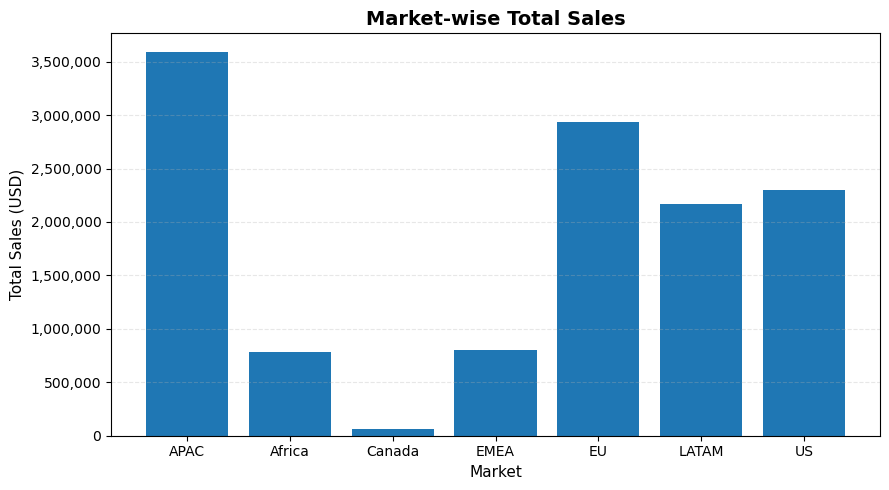

```python
plt.figure(figsize=(9,5))

plt.bar(
    market_summary.index,
    market_summary["Total_Sales"]
)

plt.title(
    "Market-wise Total Sales",
    fontsize=14,
    fontweight="bold"
)

plt.xlabel("Market", fontsize=11)

plt.ylabel("Total Sales (USD)", fontsize=11)

plt.grid(axis="y", linestyle="--", alpha=0.3)

plt.gca().yaxis.set_major_formatter(
    FuncFormatter(lambda x, pos: f"{x:,.0f}")
)

plt.tight_layout()

plt.show()
```

## 🔎 Code Explanation

This visualization is created using Matplotlib's `bar()` function to compare the total sales generated by each business market.

The chart is based on the precomputed `market_summary` table, where:

- The x-axis represents the business markets.
- The y-axis represents the total sales generated by each market.

Additional formatting, including descriptive axis labels, comma-separated number formatting, gridlines, and a clear chart title, enhances readability and makes the visualization suitable for business reporting.

## 💡 Why It Matters

Market-wise sales analysis helps organizations understand which business markets contribute most significantly to overall revenue.

Identifying high-performing and low-performing markets enables management to prioritize investments, optimize resource allocation, and develop market-specific strategies that support sustainable business growth.

## 📈 Key Observations

- APAC generated the highest total sales among all business markets.
- EU ranked second in terms of total sales.
- The US recorded the third-highest sales.
- Canada generated the lowest total sales.
- Sales performance varies considerably across different business markets.

## 🧠 Business Insights

The APAC market represents the company's strongest revenue-generating market, indicating a substantial customer base and strong market presence.

The clear variation in market-wise sales suggests that revenue opportunities differ across markets. Lower-performing markets, particularly Canada and Africa, may require focused marketing initiatives, customer acquisition strategies, or business expansion efforts to improve sales performance.

## 💼 Business Recommendation

Management should continue strengthening its presence in high-performing markets such as APAC and EU while identifying the key success factors that contribute to their strong sales performance.

For lower-performing markets, particularly Canada and Africa, management should evaluate market potential, customer demand, and competitive conditions before implementing targeted growth strategies.

## ⭐ Key Takeaway

APAC is the company's strongest revenue-generating market, while significant differences in market performance highlight opportunities for targeted business expansion.

## ✅ Analysis Summary

This analysis compared total sales across business markets and identified APAC as the company's largest revenue contributor. The findings highlight considerable differences in market performance and provide valuable insights for market prioritization and strategic business planning.

## 📊 5.5.2 Profit Analysis by Market

## 🎯 Step Purpose

The objective of this analysis is to compare the total profit generated across different business markets.

While sales measure revenue generation, profit reflects the actual financial contribution of each market. This analysis helps identify the company's most profitable markets and supports strategic business planning.

## 📊 Chart Introduction

The following bar chart illustrates the total profit generated by each business market.

By comparing market-wise profitability, we can identify the markets that contribute the greatest financial value to the company and determine whether high sales also translate into high profits.

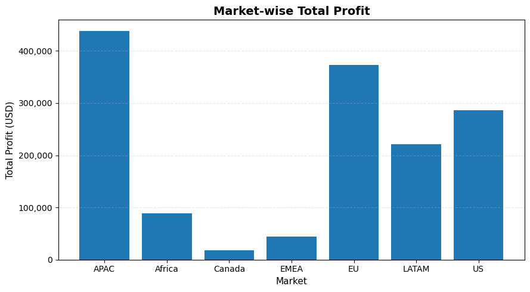

```python
plt.figure(figsize=(9,5))

plt.bar(
    market_summary.index,
    market_summary["Total_Profit"]
)

plt.title(
    "Market-wise Total Profit",
    fontsize=14,
    fontweight="bold"
)

plt.xlabel("Market", fontsize=11)

plt.ylabel("Total Profit (USD)", fontsize=11)

plt.grid(axis="y", linestyle="--", alpha=0.3)

plt.gca().yaxis.set_major_formatter(
    FuncFormatter(lambda x, pos: f"{x:,.0f}")
)

plt.tight_layout()

plt.show()
```

## 🔎 Code Explanation

This visualization is created using Matplotlib's `bar()` function to compare the total profit generated by each business market.

The chart is based on the precomputed `market_summary` table, where:

- The x-axis represents the business markets.
- The y-axis represents the total profit generated by each market.

Additional formatting, including descriptive axis labels, comma-separated number formatting, gridlines, and a clear chart title, improves readability and makes the visualization suitable for business reporting.

## 💡 Why It Matters

Profitability is a more meaningful measure of business success than sales alone because it reflects the actual financial return generated by each market.

Market-wise profit analysis helps management identify the company's most valuable markets, evaluate the effectiveness of market strategies, and prioritize investments in markets that generate the highest financial returns.

## 📈 Key Observations

- APAC generated the highest total profit among all business markets.
- EU ranked second in terms of profitability.
- The US recorded the third-highest total profit.
- Canada generated the lowest total profit.
- Profitability varies considerably across different business markets.

## 🧠 Business Insights

The APAC market not only generated the highest sales but also achieved the highest profit, indicating strong overall business performance and healthy profit generation.

Although the US generated higher sales than LATAM, the difference in profit is relatively smaller, suggesting that profit margins vary across markets. Similarly, Canada contributes very little to both sales and profit, indicating limited business presence in that market.

## 💼 Business Recommendation

Management should continue strengthening its presence in highly profitable markets such as APAC and EU while identifying the key factors driving their strong financial performance.

For lower-performing markets, particularly Canada and EMEA, management should evaluate market potential, pricing strategies, customer demand, and operational efficiency before implementing targeted growth initiatives.

## ⭐ Key Takeaway

APAC is the company's most profitable business market, while profitability differences across markets highlight opportunities for strategic market development.

## ✅ Analysis Summary

This analysis compared total profit across business markets and identified APAC as the company's strongest profit-generating market. The findings demonstrate that profitability differs across markets and emphasize the importance of evaluating both sales and profit when making market-level business decisions.

## ✅ Section Summary (5.5)

This section evaluated the company's market performance by analyzing both total sales and total profit across different business markets.

The analysis identified APAC as the strongest-performing market in terms of both revenue and profitability, followed by the EU market. It also highlighted noticeable differences in performance across markets, emphasizing that business opportunities and financial returns vary by market.

These findings provide valuable insights for market prioritization, strategic investment, and future business expansion decisions.

## ➡️ Next Analysis

While market analysis explains performance at a broader business level, the next section focuses on **Sub-Category Analysis** to identify which individual product sub-categories generate the highest sales and profits, and which ones require management attention.

# 📊 5.6 Sub-Category Analysis

## 📖 Business Scenario

While category-level analysis provides a broad overview of business performance, managers often need more detailed insights into individual product groups.

Sub-category analysis helps identify which specific product groups generate the highest sales and profits, enabling better inventory management, pricing decisions, marketing strategies, and product portfolio optimization.

This section evaluates the performance of each product sub-category using **Total Sales** and **Total Profit**.

## 🎯 Business Questions

This analysis aims to answer the following business questions:

1. Which product sub-categories generate the highest sales?
2. Which sub-categories contribute the highest profit?
3. Which sub-categories perform poorly despite generating high sales?
4. Which product groups require management attention?
5. How can product-level insights improve business profitability?

## 🎯 Overall Step Purpose

The objective of this section is to evaluate the performance of individual product sub-categories using **Total Sales** and **Total Profit**.

The analysis begins with a summary comparison of sub-category performance, followed by separate visual analyses of sales and profitability. These insights help identify the company's strongest product groups and highlight opportunities for improving product performance.

## 📋 Sub-Category Performance Summary

The following table summarizes the performance of each product sub-category using **Total Sales** and **Total Profit**.

This comparison provides a detailed overview of how individual product groups contribute to the company's overall revenue and profitability before examining sales and profit separately through visual analysis.

```python
subcategory_summary = (
    df.groupby("sub_category")
      .agg(
          Total_Sales=("sales", "sum"),
          Total_Profit=("profit", "sum")
      )
      .round(2)
      .sort_values(by="Total_Sales", ascending=False)
)

subcategory_summary.style.format({
    "Total_Sales": "{:,.0f}",
    "Total_Profit": "{:,.2f}"
})
```

| sub_category | Total_Sales | Total_Profit |
| --- | --- | --- |
| Phones | 1,706,874 | 216,717.01 |
| Copiers | 1,509,439 | 258,567.55 |
| Chairs | 1,501,682 | 141,973.80 |
| Bookcases | 1,466,559 | 161,924.42 |
| Storage | 1,127,124 | 108,461.49 |
| Appliances | 1,011,081 | 141,680.59 |
| Machines | 779,071 | 58,867.87 |
| Tables | 757,034 | -64,083.39 |
| Accessories | 749,307 | 129,626.31 |
| Binders | 461,952 | 72,449.85 |
| Furnishings | 385,609 | 46,967.43 |
| Art | 372,163 | 57,953.91 |
| Paper | 244,307 | 59,207.68 |
| Supplies | 243,090 | 22,583.26 |
| Envelopes | 170,926 | 29,601.12 |
| Fasteners | 83,254 | 11,525.42 |
| Labels | 73,433 | 15,010.51 |

## 📝 Summary Table Interpretation

The summary table reveals substantial variation in performance across the company's product sub-categories.

**Phones** generated the highest total sales, while **Copiers** produced the highest total profit, indicating exceptional profitability. Most sub-categories generated positive profits; however, **Tables** recorded an overall loss despite generating considerable sales revenue.

These findings provide a detailed understanding of product-level performance and establish the foundation for the sales and profit analyses presented in the following subsections.

## 📊 5.6.1 Sales Analysis by Sub-Category

## 🎯 Step Purpose

The objective of this analysis is to compare the total sales generated by each product sub-category.

By visualizing sub-category-wise sales performance, we can identify the products that contribute most significantly to the company's revenue and understand how sales are distributed across different product groups.

## 📊 Chart Introduction

The following horizontal bar chart illustrates the total sales generated by each product sub-category.

A horizontal bar chart is used because the dataset contains several sub-categories with relatively long names, making the comparison clearer and easier to interpret.

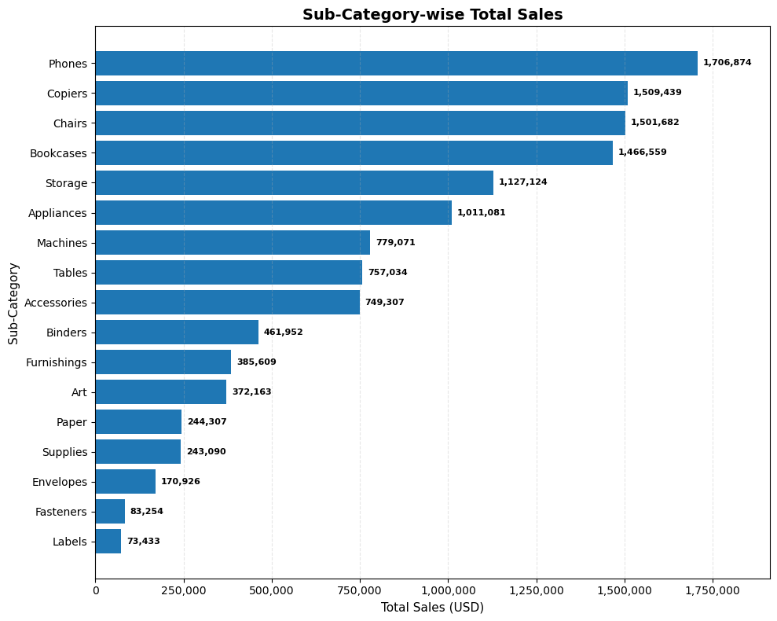

```python
plt.figure(figsize=(10, 8))

bars = plt.barh(
    subcategory_summary.index,
    subcategory_summary["Total_Sales"]
)

plt.title(
    "Sub-Category-wise Total Sales",
    fontsize=14,
    fontweight="bold"
)

plt.xlabel(
    "Total Sales (USD)",
    fontsize=11
)

plt.ylabel(
    "Sub-Category",
    fontsize=11
)

# Display highest sales at the top
plt.gca().invert_yaxis()

# Format x-axis values with commas
plt.gca().xaxis.set_major_formatter(
    FuncFormatter(lambda x, pos: f"{x:,.0f}")
)

# Gridlines
plt.grid(
    axis="x",
    linestyle="--",
    alpha=0.3
)

# Add some extra space on the right for value labels
plt.xlim(
    0,
    subcategory_summary["Total_Sales"].max() * 1.12
)

# Add value labels
for bar in bars:
    width = bar.get_width()

    plt.text(
        width + 15000,
        bar.get_y() + bar.get_height() / 2,
        f"{width:,.0f}",
        va="center",
        fontsize=8,
        fontweight="bold"
    )

plt.tight_layout()

plt.show()
```

## 🔎 Code Explanation

This visualization uses a horizontal bar chart (`barh()`) to compare the total sales generated by each product sub-category.

The chart is based on the precomputed `subcategory_summary` table, where:

- The y-axis represents the product sub-categories.
- The x-axis represents the total sales generated by each sub-category.

The sub-categories are sorted in descending order of sales so that the highest-performing products appear at the top of the chart. Value labels are displayed beside each bar to improve readability and allow quick comparison of sales performance across product groups.

## 💡 Why It Matters

Sub-category sales analysis provides a detailed understanding of which specific product groups drive the company's revenue.

Unlike category-level analysis, this product-level view helps management identify best-selling products, prioritize inventory planning, optimize marketing efforts, and allocate resources more effectively.

## 📈 Key Observations

- Phones generated the highest total sales among all product sub-categories.
- Copiers and Chairs ranked second and third in terms of sales, respectively.
- Bookcases and Storage also contributed significantly to overall revenue.
- Labels and Fasteners generated the lowest sales.
- Sales performance varies considerably across different product sub-categories.

## 🧠 Business Insights

A relatively small number of product sub-categories account for a large proportion of the company's total sales, indicating that customer demand is concentrated around certain products such as Phones, Copiers, and Chairs.

At the same time, several sub-categories contribute comparatively little to total revenue. These lower-performing products may require targeted marketing efforts, portfolio evaluation, or inventory optimization to improve their business contribution.

## 💼 Business Recommendation

Management should continue investing in high-performing sub-categories such as Phones, Copiers, and Chairs by ensuring adequate inventory availability and supporting them through effective marketing strategies.

Lower-selling sub-categories should be evaluated to determine whether improvements in pricing, promotion, product assortment, or inventory management can enhance their sales performance.

## ⭐ Key Takeaway

A small group of product sub-categories generates a substantial share of the company's total sales, making these products key drivers of overall business performance.

## ✅ Analysis Summary

This analysis compared total sales across all product sub-categories and identified Phones as the company's highest-selling product group. The results highlight clear differences in product-level performance and provide valuable insights for inventory planning, marketing strategies, and product portfolio management.

## 📊 5.6.2 Profit Analysis by Sub-Category

## 🎯 Step Purpose

The objective of this analysis is to compare the total profit generated by each product sub-category.

While sales indicate revenue generation, profit reflects the actual financial contribution of each product group. This analysis helps identify the company's most profitable products as well as sub-categories that require immediate management attention due to poor profitability.

## 📊 Chart Introduction

The following horizontal bar chart illustrates the total profit generated by each product sub-category.

This visualization highlights the company's most profitable product groups while also identifying sub-categories that generate low or even negative profits despite contributing to sales.

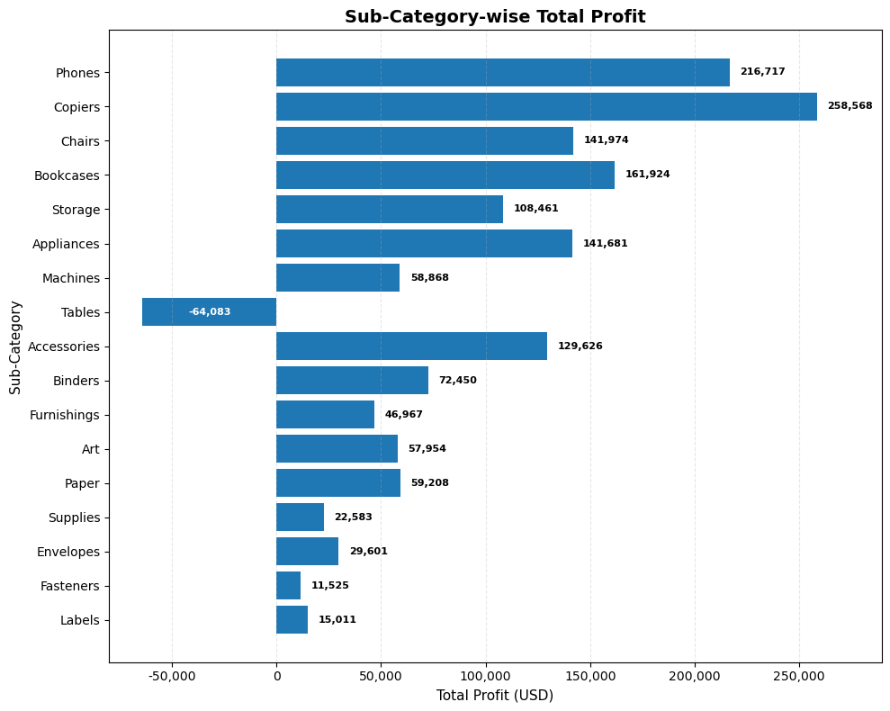

```python
plt.figure(figsize=(10, 8))

bars = plt.barh(
    subcategory_summary.index,
    subcategory_summary["Total_Profit"]
)

plt.title(
    "Sub-Category-wise Total Profit",
    fontsize=14,
    fontweight="bold"
)

plt.xlabel(
    "Total Profit (USD)",
    fontsize=11
)

plt.ylabel(
    "Sub-Category",
    fontsize=11
)

# Display highest profit at the top
plt.gca().invert_yaxis()

# Format x-axis values with commas
plt.gca().xaxis.set_major_formatter(
    FuncFormatter(lambda x, pos: f"{x:,.0f}")
)

# Gridlines
plt.grid(
    axis="x",
    linestyle="--",
    alpha=0.3
)

# Add space for value labels
profit_min = subcategory_summary["Total_Profit"].min()
profit_max = subcategory_summary["Total_Profit"].max()

plt.xlim(
    profit_min * 1.25,
    profit_max * 1.12
)

# Add value labels
for bar in bars:

    width = bar.get_width()

    if width >= 0:

        plt.text(
            width + 5000,
            bar.get_y() + bar.get_height()/2,
            f"{width:,.0f}",
            va="center",
            ha="left",
            fontsize=8,
            fontweight="bold"
        )

    else:

        # Display negative value inside the bar
        plt.text(
            width / 2,
            bar.get_y() + bar.get_height()/2,
            f"{width:,.0f}",
            va="center",
            ha="center",
            fontsize=8,
            fontweight="bold",
            color="white"
        )

plt.tight_layout()

plt.show()
```

## 🔎 Code Explanation

This visualization uses a horizontal bar chart (`barh()`) to compare the total profit generated by each product sub-category.

The chart is based on the `subcategory_summary` table, where:

- The y-axis represents the product sub-categories.
- The x-axis represents the total profit earned by each sub-category.

## 💡 Why It Matters

Profitability is a more meaningful measure of business performance than sales alone. While high sales indicate strong revenue generation, only profitable products contribute positively to the organization's financial success.

This analysis helps identify the most profitable product groups as well as products that require pricing, cost, or inventory improvements.

## 📈 Key Observations

- Copiers generated the highest total profit among all sub-categories.
- Phones ranked second in terms of total profit despite generating the highest sales.
- Bookcases, Chairs, and Appliances also contributed significantly to overall profitability.
- Tables recorded a **negative total profit**, making it the only loss-making sub-category.
- Profitability varies considerably across different product sub-categories.

## 🧠 Business Insights

The analysis shows that high sales do not always translate into high profitability. Although Phones generated the highest sales revenue, Copiers delivered the greatest profit.

More importantly, the Tables sub-category generated substantial sales but resulted in an overall financial loss. This indicates potential issues related to excessive discounting, high procurement costs, or inefficient pricing strategies.

These findings highlight the importance of evaluating both revenue and profit when assessing product performance.

## 💼 Business Recommendation

The company should continue investing in highly profitable sub-categories such as Copiers and Phones by maintaining sufficient inventory and supporting them through targeted marketing initiatives.

Management should immediately investigate the Tables sub-category to determine the reasons behind its negative profitability. Pricing policies, discount strategies, procurement costs, and supplier contracts should be reviewed to improve its financial performance.

## ⭐ Key Takeaway

Profitability analysis reveals that the highest-selling products are not always the most profitable, and it identifies **Tables** as the only sub-category currently operating at a loss.

## ✅ Analysis Summary

This analysis compared the profitability of all product sub-categories and identified Copiers as the company's most profitable product group. It also revealed that the Tables sub-category generated an overall loss despite strong sales performance. These findings provide valuable insights for pricing decisions, cost optimization, and product portfolio management.

# ✅ Section Summary (5.6)

The Sub-Category Analysis provided a detailed evaluation of sales and profit across individual product groups. While Phones emerged as the highest-selling sub-category, Copiers generated the highest overall profit, demonstrating that strong sales do not always result in maximum profitability.

A particularly important finding was that the Tables sub-category recorded an overall loss despite generating substantial sales revenue. This highlights the importance of analyzing both sales and profit together when evaluating product performance.

Overall, this section identified the company's strongest and weakest product groups and provided actionable insights to support inventory planning, pricing strategies, and product portfolio optimization.

## ➡️ Next Analysis

Having evaluated product performance across categories, customer segments, regions, markets, and sub-categories, the next step is to analyze **Shipping Mode Performance**.

The following section examines how different shipping methods contribute to the company's sales and profitability, helping assess the operational effectiveness of various delivery options.

# 📊 5.7 Shipping Mode Analysis

## 📖 Business Scenario

Shipping plays an important role in customer satisfaction, operational efficiency, and overall business performance.

Different shipping modes vary in terms of delivery speed, cost, and customer preference. Understanding how each shipping mode contributes to sales and profitability helps businesses optimize logistics, improve customer service, and make better operational decisions.

This section evaluates the performance of each shipping mode using **Total Sales** and **Total Profit**.

## 🎯 Business Questions

This analysis aims to answer the following business questions:

1. Which shipping mode generates the highest sales?
2. Which shipping mode contributes the highest profit?
3. Do faster shipping methods generate higher revenue?
4. Which shipping mode performs least effectively?
5. How can shipping performance be optimized to improve overall business profitability?

## 🎯 Overall Step Purpose

The objective of this section is to evaluate the performance of different shipping modes using **Total Sales** and **Total Profit**.

The analysis begins with a summary comparison of shipping modes, followed by separate visual analyses of sales and profitability. These insights help identify the company's most effective delivery methods and support data-driven logistics and operational decisions.

## 📋 Shipping Mode Performance Summary

The following table summarizes the performance of each shipping mode using **Total Sales** and **Total Profit**.

This comparison provides an overview of how different shipping methods contribute to the company's overall revenue and profitability before examining sales and profit separately through visual analysis.

```python
shipping_summary = (
    df.groupby("ship_mode")
      .agg(
          Total_Sales=("sales", "sum"),
          Total_Profit=("profit", "sum")
      )
      .round(2)
      .sort_values(by="Total_Sales", ascending=False)
)

shipping_summary.style.format({
    "Total_Sales": "{:,.0f}",
    "Total_Profit": "{:,.2f}"
})
```

| ship_mode | Total_Sales | Total_Profit |
| --- | --- | --- |
| Standard Class | 7,578,889 | 890,596.02 |
| Second Class | 2,565,747 | 294,161.06 |
| First Class | 1,831,067 | 208,104.68 |
| Same Day | 667,202 | 76,173.07 |

## 📝 Summary Table Interpretation

The summary table indicates that **Standard Class** is the company's dominant shipping mode, contributing the highest sales as well as the highest overall profit.

The remaining shipping modes contribute progressively smaller shares of revenue and profit, with **Same Day** generating the lowest sales and profitability. These findings establish a baseline for the detailed visual analyses presented in the following subsections.

## 📊 5.7.1 Sales Analysis by Shipping Mode

## 🎯 Step Purpose

The objective of this analysis is to compare the total sales generated through different shipping modes.

By evaluating sales across shipping methods, we can identify customer preferences and understand which delivery options contribute most significantly to the company's revenue.

## 📊 Chart Introduction

The following bar chart illustrates the total sales generated by each shipping mode.

Since the dataset contains only four shipping methods, a vertical bar chart provides a clear and effective comparison of their sales performance.

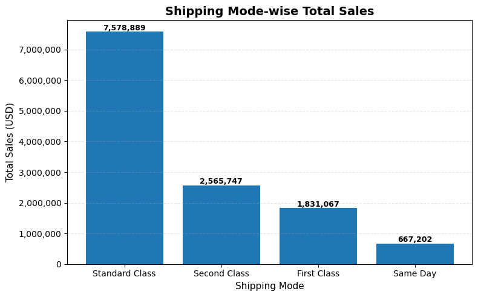

```python
plt.figure(figsize=(8,5))

bars = plt.bar(
    shipping_summary.index,
    shipping_summary["Total_Sales"]
)

plt.title(
    "Shipping Mode-wise Total Sales",
    fontsize=14,
    fontweight="bold"
)

plt.xlabel(
    "Shipping Mode",
    fontsize=11
)

plt.ylabel(
    "Total Sales (USD)",
    fontsize=11
)

plt.grid(
    axis="y",
    linestyle="--",
    alpha=0.3
)

plt.gca().yaxis.set_major_formatter(
    FuncFormatter(lambda x, pos: f"{x:,.0f}")
)

# Add value labels
for bar in bars:
    height = bar.get_height()

    plt.text(
        bar.get_x() + bar.get_width()/2,
        height + 50000,
        f"{height:,.0f}",
        ha="center",
        fontsize=9,
        fontweight="bold"
    )

plt.tight_layout()

plt.show()
```

## 🔎 Code Explanation

This visualization uses a vertical bar chart (`bar()`) to compare the total sales generated by each shipping mode.

The x-axis represents the different shipping methods, while the y-axis represents the corresponding total sales. Value labels are displayed above each bar to improve readability and enable quick comparison of sales performance across shipping modes.

## 💡 Why It Matters

Shipping mode analysis helps businesses understand customer delivery preferences and evaluate how different shipping options contribute to overall revenue.

These insights support operational planning, logistics management, and customer service strategies by identifying the most frequently used shipping methods.

## 📈 Key Observations

- Standard Class generated the highest total sales among all shipping modes.
- Second Class ranked second in terms of sales.
- First Class generated lower sales than both Standard and Second Class.
- Same Day recorded the lowest total sales.
- Customer purchases are heavily concentrated in Standard Class shipping.

## 🧠 Business Insights

The results indicate that customers strongly prefer Standard Class shipping, suggesting that affordability and acceptable delivery times are more important than faster delivery options.

Although premium shipping modes offer quicker delivery, they contribute a much smaller share of overall revenue, indicating relatively lower customer demand.

## 💼 Business Recommendation

The company should continue optimizing Standard Class shipping by maintaining reliable delivery performance and operational efficiency.

Premium shipping options such as First Class and Same Day should be evaluated to determine whether pricing, service quality, or promotional strategies can increase customer adoption.

## ⭐ Key Takeaway

Standard Class is the company's primary revenue-generating shipping method, while faster shipping options contribute comparatively smaller shares of total sales.

## ✅ Analysis Summary

This analysis compared total sales across different shipping modes and identified Standard Class as the company's dominant delivery option. The findings provide valuable insights into customer shipping preferences and support data-driven logistics planning.

## 📊 5.7.2 Profit Analysis by Shipping Mode

## 🎯 Step Purpose

The objective of this analysis is to compare the total profit generated by each shipping mode.

While sales indicate customer demand, profit reflects the financial contribution of each delivery method. This analysis helps identify which shipping modes create the greatest business value.

## 📊 Chart Introduction

The following bar chart illustrates the total profit generated by each shipping mode.

The visualization compares the profitability of different shipping methods, allowing us to identify the company's most financially effective delivery options.

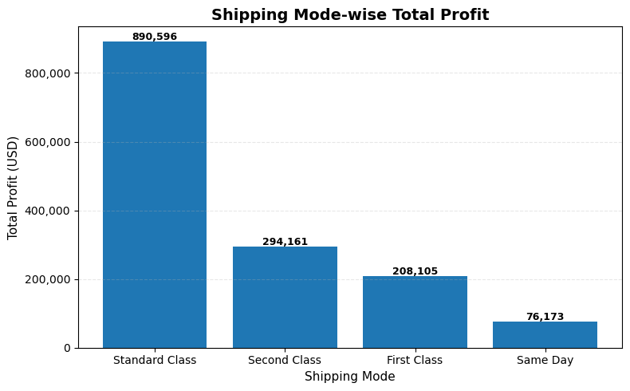

```python
plt.figure(figsize=(8,5))

bars = plt.bar(
    shipping_summary.index,
    shipping_summary["Total_Profit"]
)

plt.title(
    "Shipping Mode-wise Total Profit",
    fontsize=14,
    fontweight="bold"
)

plt.xlabel(
    "Shipping Mode",
    fontsize=11
)

plt.ylabel(
    "Total Profit (USD)",
    fontsize=11
)

plt.grid(
    axis="y",
    linestyle="--",
    alpha=0.3
)

plt.gca().yaxis.set_major_formatter(
    FuncFormatter(lambda x, pos: f"{x:,.0f}")
)

# Add value labels
for bar in bars:

    height = bar.get_height()

    plt.text(
        bar.get_x() + bar.get_width()/2,
        height + 5000,
        f"{height:,.0f}",
        ha="center",
        fontsize=9,
        fontweight="bold"
    )

plt.tight_layout()

plt.show()
```

## 🔎 Code Explanation

This visualization uses a vertical bar chart (`bar()`) to compare the total profit generated by each shipping mode.

The x-axis represents the available shipping methods, while the y-axis represents the corresponding total profit. Value labels are displayed above each bar to improve readability and facilitate quick comparison of profitability across different delivery options.

## 💡 Why It Matters

While sales indicate customer demand, profit reflects the actual financial contribution of each shipping method.

Evaluating profitability across shipping modes helps the company assess operational efficiency, understand the financial impact of different delivery options, and make informed decisions regarding logistics and shipping strategies.

## 📈 Key Observations

- Standard Class generated the highest total profit among all shipping modes.
- Second Class ranked second in terms of profitability.
- First Class produced lower profit than Standard and Second Class.
- Same Day generated the lowest total profit.
- All shipping modes contributed positively to the company's overall profitability.

## 🧠 Business Insights

The profitability pattern closely follows the sales distribution, indicating that shipping modes with higher customer adoption also generate higher financial returns.

Standard Class is both the most preferred and the most profitable shipping method, suggesting that customers value its balance between delivery speed and shipping cost.

## 💼 Business Recommendation

The company should continue strengthening Standard Class shipping by maintaining reliable delivery performance and cost efficiency.

Management should also evaluate opportunities to increase the adoption of premium shipping options through promotional offers, improved service quality, or pricing strategies while ensuring operational profitability.

## ⭐ Key Takeaway

Standard Class is both the highest-selling and the most profitable shipping method, making it the company's most valuable delivery option.

## ✅ Analysis Summary

This analysis compared the profitability of different shipping modes and identified Standard Class as the company's strongest-performing delivery option. The findings demonstrate that customer preference for Standard Class translates directly into higher business profitability, providing valuable insights for logistics and operational planning.

## ✅ Section Summary (5.7)

The Shipping Mode Analysis evaluated the performance of different delivery methods using both sales and profit.

The results showed that **Standard Class** dominates all shipping modes in terms of both revenue generation and profitability, indicating that it is the preferred delivery option among customers. Second Class and First Class contribute moderate business value, while Same Day accounts for the smallest share of both sales and profit.

Overall, this section highlights customer shipping preferences and provides actionable insights for optimizing logistics operations, improving delivery strategies, and supporting data-driven business decisions.

## ➡️ Next Analysis

Having evaluated the performance of products, customers, regions, markets, and shipping methods, the next step is to examine the impact of **Discounts** on business performance.

The following section investigates how different discount levels influence sales and profitability, helping identify pricing strategies that maximize revenue while maintaining healthy profit margins.

# 📊 5.8 Discount Analysis

## 📖 Business Scenario

Discounts are commonly used to attract customers, increase sales volume, and remain competitive in the market. However, excessive discounting can significantly reduce profit margins and negatively impact overall business performance.

This section examines how discounts influence both sales and profitability, helping determine whether higher discounts contribute to sustainable business growth or reduce financial performance.

## 🎯 Business Questions

This analysis aims to answer the following business questions:

1. How are discounts distributed across customer orders?
2. Does increasing the discount lead to higher or lower profit?
3. Are highly discounted orders generally less profitable?
4. Is there an optimal discount range that balances sales and profitability?
5. How should the company manage discount strategies to maximize business performance?

## 🎯 Overall Step Purpose

The objective of this section is to analyze the relationship between discounts and business performance.

The analysis begins by examining the distribution of discounts applied across customer orders. It then investigates how discount levels affect profitability, enabling the identification of pricing strategies that maximize revenue while maintaining healthy profit margins.

## 📊 5.8.1 Discount Distribution

## 🎯 Step Purpose

The objective of this analysis is to examine how discounts are distributed across customer orders.

Understanding the frequency of different discount levels helps identify the company's pricing practices and provides a foundation for analyzing the relationship between discounts and profitability in the next step.

## 📊 Chart Introduction

The following histogram illustrates the distribution of discount values applied to customer orders.

The x-axis represents the discount percentage, while the y-axis shows the number of orders within each discount range. This visualization helps identify the most frequently used discount levels and highlights whether higher discounts are applied frequently or only in specific cases.

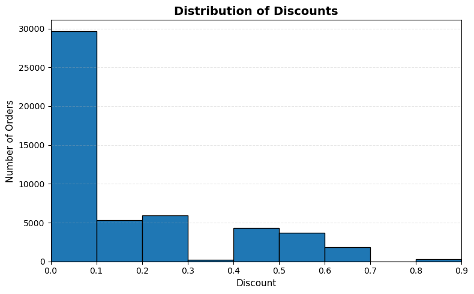

```python
plt.figure(figsize=(8,5))

# Define discount intervals (bins)
bins = np.arange(0, 0.91, 0.1)

plt.hist(
    df["discount"],
    bins=bins,
    edgecolor="black"
)

plt.title(
    "Distribution of Discounts",
    fontsize=14,
    fontweight="bold"
)

plt.xlabel(
    "Discount",
    fontsize=11
)

plt.ylabel(
    "Number of Orders",
    fontsize=11
)

# Set x-axis limits and ticks
plt.xlim(0, 0.9)

plt.xticks(
    np.arange(0, 0.91, 0.1)
)

plt.grid(
    axis="y",
    linestyle="--",
    alpha=0.3
)

plt.tight_layout()

plt.show()
```

## 🔎 Code Explanation

This visualization uses a histogram (`hist()`) to examine the distribution of discount values across customer orders.

The x-axis represents the discount percentage applied to orders, while the y-axis represents the number of orders within each discount interval. Custom bins are used to align the histogram with the discount ranges present in the dataset, providing a clear view of the company's discounting practices.

## 💡 Why It Matters

Before evaluating the impact of discounts on profitability, it is essential to understand how frequently different discount levels are applied.

Analyzing the distribution of discounts provides insight into the company's pricing strategy and establishes a foundation for assessing whether higher discounts contribute positively or negatively to business performance.

## 🧠 Business Insights

The distribution indicates that the company primarily relies on low-discount pricing to generate sales.

Higher discounts are used selectively, suggesting that they are likely offered during promotional campaigns, inventory clearance, or special business situations rather than as part of regular pricing practices.

## 💼 Business Recommendation

The company should continue applying discounts strategically instead of offering large discounts frequently.

Future pricing decisions should be supported by profitability analysis to ensure that higher discounts generate sufficient business value without significantly reducing profit margins.

## ⭐ Key Takeaway

The majority of customer orders are completed with little or no discount, while high-discount transactions occur relatively infrequently.

## ✅ Analysis Summary

This analysis examined the distribution of discounts applied across customer orders and found that low-discount transactions dominate the dataset. These findings provide an important foundation for the next analysis, which investigates how different discount levels influence business profitability.

## 📊 5.8.2 Discount vs Profit Analysis

## 🎯 Step Purpose

The objective of this analysis is to examine the relationship between discount levels and profit.

By comparing discounts with the corresponding profit earned on each order, we can determine whether higher discounts improve business performance or reduce profitability. This analysis helps evaluate the effectiveness of the company's discount strategy.

## 📊 Chart Introduction

The following scatter plot illustrates the relationship between discounts and profit for individual customer orders.

Each point represents a single order, where the x-axis indicates the discount applied and the y-axis represents the corresponding profit. The red regression line summarizes the overall trend between discounts and profitability, making it easier to identify whether increasing discounts generally increase or decrease profit.

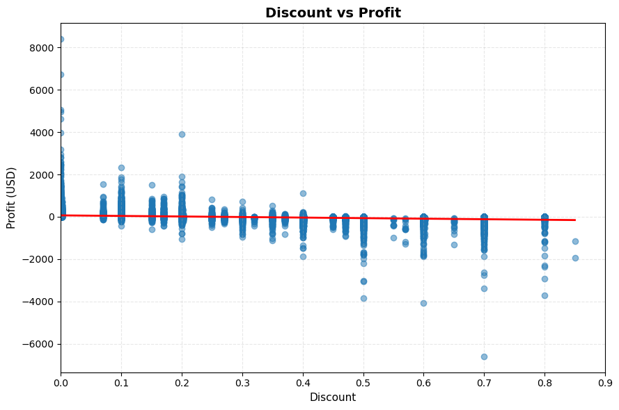

```python
plt.figure(figsize=(9,6))

sns.regplot(
    data=df,
    x="discount",
    y="profit",
    scatter_kws={
        "alpha": 0.5
    },
    line_kws={
        "color": "red",
        "linewidth": 2
    }
)

plt.title(
    "Discount vs Profit",
    fontsize=14,
    fontweight="bold"
)

plt.xlabel(
    "Discount",
    fontsize=11
)

plt.ylabel(
    "Profit (USD)",
    fontsize=11
)

plt.xlim(0, 0.9)

plt.xticks(np.arange(0, 0.91, 0.1))

plt.grid(
    linestyle="--",
    alpha=0.3
)

plt.tight_layout()

plt.show()
```

## 🔎 Code Explanation

- `sns.regplot()` creates a scatter plot and automatically fits a linear regression (trend) line.
- The x-axis represents the discount applied to each order, while the y-axis represents the corresponding profit.
- Each point in the scatter plot represents one individual customer order.
- The red regression line summarizes the overall relationship between discount and profit.
- `scatter_kws={"alpha":0.5}` makes the data points semi-transparent, reducing overlap and improving readability.
- `line_kws={"color":"red","linewidth":2}` customizes the regression line for better visibility.
- `plt.xlim(0,0.9)` limits the x-axis to the observed discount range.
- `plt.xticks(np.arange(0,0.91,0.1))` displays discount values at regular intervals.
- `plt.grid()` adds light gridlines, making the chart easier to interpret.

## 💡 Why It Matters

Understanding the relationship between discount and profit is essential for evaluating the effectiveness of the company's pricing strategy.

While discounts can encourage customer purchases and increase sales volume, excessive discounting may significantly reduce profit margins. This analysis helps determine whether higher discounts contribute positively to business performance or negatively impact profitability.

## 📈 Key Observations

- Most customer orders are concentrated between **0% and 20% discount**.
- Orders with **little or no discount** contain the highest profit values.
- As discount levels increase, profitable orders become less frequent.
- High discount levels (50%–80%) show a greater concentration of negative profit values.
- The regression line has a **slightly downward slope**, indicating an overall negative relationship between discount and profit.

## 💼 Business Insights

The analysis indicates that increasing discounts generally leads to lower profitability.

Although some discounted orders remain profitable, larger discounts are associated with a greater risk of losses. This suggests that discounts should be applied strategically rather than uniformly across all products.

## 💼 Business Recommendation

- Review products that frequently require high discounts.
- Avoid offering excessive discounts on products with already low profit margins.
- Implement targeted promotional campaigns instead of applying large discounts uniformly across products.
- Continuously monitor the profitability of discounted orders to optimize future pricing strategies.

## ⭐ Key Takeaway

The scatter plot and regression analysis indicate a negative relationship between discount and profit. While discounts may help increase sales, excessive discounting reduces profitability and should be carefully managed to ensure sustainable business growth.

## ✅ Analysis Summary

This analysis examined the relationship between discount and profit using a scatter plot with a regression line.

The results show that orders with lower discounts generally generate higher profits, whereas heavily discounted orders are more likely to produce losses. The downward trend of the regression line confirms that increasing discounts tend to reduce overall profitability.

These findings emphasize the importance of adopting a balanced discount strategy that attracts customers while protecting business margins.

## ✅ Section Summary (5.8)

The Discount Analysis examined both the distribution of discounts across customer orders and their impact on profitability.

The histogram revealed that most orders receive little or no discount, indicating that the company primarily follows a low-discount pricing strategy. Higher discount levels are used relatively infrequently and appear to be reserved for specific promotional or business situations.

The scatter plot with a regression line further demonstrated a negative relationship between discount and profit. While discounts may help increase sales, excessive discounting generally reduces profitability and increases the likelihood of loss-making transactions.

Overall, this section highlights that an effective discount strategy should balance customer acquisition with long-term profitability. Rather than relying on frequent large discounts, the company should adopt targeted promotional strategies that maximize both sales performance and profit margins.

## ➡️ Next Analysis

After evaluating how discounts influence profitability, the next step is to analyze the overall distribution of profits across customer orders.

The following section explores how profits are distributed, identifies the presence of profit and loss outliers, and provides a deeper understanding of the company's financial performance at the transaction level.

# 📊 5.9 Profit Analysis

## 📖 Business Scenario

Profit is one of the most important indicators of a company's financial performance. While sales measure revenue generation, profit reflects how effectively the company converts revenue into earnings after accounting for costs and discounts.

Analyzing the distribution of profits helps identify whether the majority of customer orders are profitable, whether loss-making transactions are common, and whether there are unusually large profits or losses that may significantly influence overall business performance.

## 🎯 Business Questions

1. How are profits distributed across customer orders?
2. Do most orders generate small profits or large profits?
3. Are loss-making transactions common?
4. Are there any unusually high-profit or high-loss orders (outliers)?

## 🎯 Overall Step Purpose

The objective of this section is to understand the overall distribution of profits across all customer orders.

This analysis helps evaluate the financial performance of individual transactions, identify the presence of profitable and loss-making orders, and detect unusual profit values that may require further business investigation.

## 📊 5.9.1 Profit Distribution

## 🎯 Step Purpose

The objective of this analysis is to examine how profit values are distributed across all customer orders.

A histogram helps identify whether most transactions generate small profits, large profits, or losses, while also revealing the overall spread of profit values.

## 📊 Chart Introduction

The following histogram illustrates the distribution of profit earned from individual customer orders.

The x-axis represents profit values, while the y-axis shows the number of orders within each profit range. This visualization provides an overview of how profits are distributed across the entire dataset.

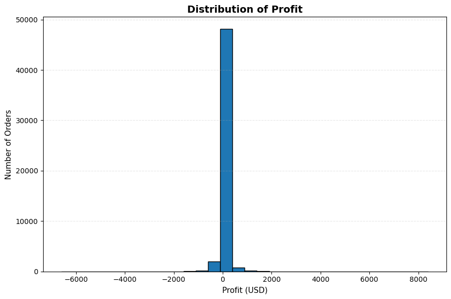

```python
plt.figure(figsize=(9,6))

plt.hist(
    df["profit"],
    bins=30,
    edgecolor="black"
)

plt.title(
    "Distribution of Profit",
    fontsize=14,
    fontweight="bold"
)

plt.xlabel(
    "Profit (USD)",
    fontsize=11
)

plt.ylabel(
    "Number of Orders",
    fontsize=11
)

plt.grid(
    axis="y",
    linestyle="--",
    alpha=0.3
)

plt.tight_layout()

plt.show()
```

## 🔎 Code Explanation

- `plt.figure(figsize=(9,6))`
  - Creates a figure of size 9 × 6 inches for better readability.
- `plt.hist(df["profit"], bins=30, edgecolor="black")`
  - Creates a histogram of profit values.
  - `bins=30` divides the entire profit range into 30 intervals.
  - `edgecolor="black"` adds black borders around each bar for better visibility.
- `plt.title("Distribution of Profit", fontsize=14, fontweight="bold")`
  - Adds a descriptive title to the chart.
- `plt.xlabel("Profit (USD)", fontsize=11)`
  - Labels the x-axis with profit values.
- `plt.ylabel("Number of Orders", fontsize=11)`
  - Labels the y-axis with the frequency of orders.
- `plt.grid(axis="y", linestyle="--", alpha=0.3)`
  - Adds horizontal gridlines to improve readability.
- `plt.tight_layout()`
  - Automatically adjusts spacing to prevent overlapping chart elements.
- `plt.show()`
  - Displays the completed histogram.

## 💡 Why It Matters

Understanding the distribution of profit is essential because it reveals how profits are spread across individual customer orders.

Instead of looking only at total profit, this analysis helps determine whether profits are consistently earned from most transactions or whether the business depends on a few highly profitable orders.

It also highlights the presence of loss-making transactions and prepares us for identifying profit outliers in the next analysis.

## 📈 Key Observations

- The majority of customer orders generate profits close to zero.
- The distribution is highly concentrated around small profit values.
- A relatively small number of orders generate exceptionally high profits.
- Loss-making orders are present and extend into the negative profit region.
- The profit distribution is highly skewed rather than normally distributed.
- Both extremely high profits and large losses indicate the presence of outliers.

## 🧠 Business Insights

- The company earns modest profits from most customer orders rather than consistently large profits.
- Overall business profitability is influenced by a relatively small number of highly profitable transactions.
- Some orders result in significant losses, suggesting potential issues such as excessive discounts, high operational costs, or low-margin products.
- Since the distribution is highly skewed, relying solely on average profit may not accurately represent business performance.

## 💼 Business Recommendation

- Investigate highly profitable orders to identify successful products, customer segments, or pricing strategies that can be replicated.
- Analyze loss-making transactions to determine whether discounts, shipping costs, or product pricing are reducing profitability.
- Review pricing and discount policies to minimize unnecessary losses while maintaining competitiveness.
- Perform a detailed outlier analysis before making strategic decisions based on average profit values.

## ⭐ Key Takeaway

Most customer orders generate relatively small profits, while only a few transactions contribute exceptionally high profits or significant losses, indicating an uneven distribution of profitability across orders.

## ✅ Analysis Summary

The profit distribution shows that the majority of orders produce small profits, whereas only a limited number of transactions generate extremely high profits or substantial losses. This uneven distribution suggests that profit is heavily influenced by outlier transactions. Therefore, identifying and analyzing these outliers is essential for gaining a more accurate understanding of business performance.

## 📊 5.9.2 Profit Outlier Analysis (Box Plot)

## 🎯 Step Purpose

The objective of this analysis is to identify profit outliers using a box plot.

While the histogram showed the overall distribution of profits, it does not clearly highlight extreme values. A box plot summarizes the spread of the data and makes it easy to identify unusually high-profit and high-loss orders.

This analysis helps determine whether a few extreme transactions are significantly influencing overall business profitability.

## 📊 Chart Introduction

The following box plot visualizes the distribution of profit across all customer orders.

It displays the median profit, the interquartile range (IQR), and any observations that fall significantly above or below the normal profit range. Points outside the whiskers represent potential profit outliers.

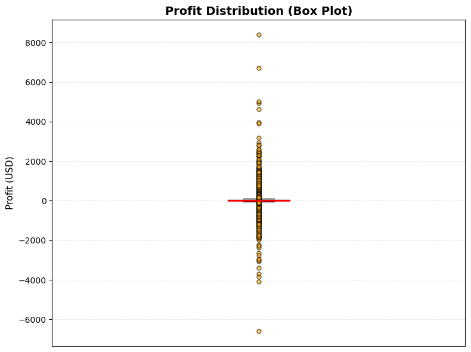

```python
plt.figure(figsize=(8,6))

plt.boxplot(
    df["profit"],
    vert=True,
    patch_artist=True,
    boxprops=dict(facecolor="skyblue", color="black"),
    medianprops=dict(color="red", linewidth=2),
    whiskerprops=dict(color="black"),
    capprops=dict(color="black"),
    flierprops=dict(
        marker="o",
        markerfacecolor="orange",
        markeredgecolor="black",
        markersize=5,
        alpha=0.6
    )
)
plt.xticks([])
plt.xlabel("")

plt.title(
    "Profit Distribution (Box Plot)",
    fontsize=14,
    fontweight="bold"
)

plt.ylabel(
    "Profit (USD)",
    fontsize=11
)

plt.grid(
    axis="y",
    linestyle="--",
    alpha=0.3
)

plt.tight_layout()

plt.show()
```

## 🔎 Code Explanation

- `plt.figure(figsize=(8,6))`
  - Creates a figure of size 8 × 6 inches for clear visualization.
- `plt.boxplot(df["profit"], ...)`
  - Creates a box plot to summarize the distribution of profit.
  - The box represents the Interquartile Range (IQR), containing the middle 50% of profit values.
  - The red line inside the box represents the median profit.
  - The whiskers show the normal spread of profit values.
  - The orange circles represent outliers (extremely high-profit or high-loss orders).
- `patch_artist=True`
  - Allows the box to be filled with color.
- `boxprops`
  - Customizes the appearance of the box.
- `medianprops`
  - Highlights the median using a thick red line.
- `whiskerprops` and `capprops`
  - Customize the whiskers and end caps.
- `flierprops`
  - Formats the outlier points using orange circular markers.
- `plt.title()`
  - Adds a descriptive title.
- `plt.ylabel()`
  - Labels the Profit axis.
- `plt.xticks([])`
  - Removes the unnecessary x-axis label to improve readability.
- `plt.grid(axis="y", linestyle="--", alpha=0.3)`
  - Adds horizontal gridlines for easier comparison.
- `plt.tight_layout()`
  - Adjusts spacing automatically.
- `plt.show()`
  - Displays the final box plot.

## 💡 Why It Matters

A histogram provides the overall distribution of profit, but it does not clearly identify extreme observations.

A box plot summarizes the distribution using the median, quartiles, whiskers, and outliers. It allows us to quickly detect unusually profitable or highly loss-making orders that may significantly influence overall business performance.

Understanding these outliers helps businesses investigate exceptional transactions before making strategic decisions.

## 📈 Key Observations

1. The median profit is close to zero, indicating that most orders generate relatively small profits.
2. The interquartile range (IQR) is very narrow, suggesting that the middle 50% of orders have similar profit values.
3. A large number of profit outliers are present on both the positive and negative sides.
4. Positive outliers reach profits above **8,000 USD**, representing exceptionally profitable transactions.
5. Negative outliers extend below **-6,000 USD**, indicating a few orders that incurred substantial losses.
6. The presence of numerous outliers shows that profit is highly variable across different orders.

## 🧠 Business Insights

- Most customer orders contribute only modest profits, while a relatively small number of orders have a disproportionate impact on overall profitability.
- Highly profitable orders may represent premium products, bulk purchases, or successful pricing strategies that should be studied and replicated.
- Significant loss-making orders may result from excessive discounts, costly shipping, low-margin products, or pricing inefficiencies.
- Because profit contains many extreme values, average profit alone may not accurately reflect the company's overall financial performance.

## 💼 Business Recommendation

- Investigate highly profitable orders to identify successful products, customer segments, and sales strategies.
- Analyze severely loss-making orders to determine whether discounts, shipping costs, returns, or pricing decisions caused the losses.
- Review pricing and discount policies for products frequently associated with negative-profit outliers.
- Consider monitoring outlier transactions separately through business dashboards to support faster decision-making and risk management.

## ⭐ Key Takeaway

Although most customer orders generate relatively small profits, a limited number of extremely profitable and highly loss-making transactions have a significant influence on overall business profitability.

## ✅ Analysis Summary

The box plot confirms that profit is concentrated within a narrow range for most orders, while numerous extreme positive and negative outliers exist. These outliers play an important role in shaping overall profitability and should be investigated separately to identify successful business practices and minimize financial losses.

# ✅ Section Summary (5.9)

The Profit Analysis section examined how profits are distributed across customer orders.

Using both the histogram and box plot, we found that most transactions generate relatively small profits, while a limited number of orders produce exceptionally high profits or significant losses. The presence of numerous outliers indicates that overall profitability is strongly influenced by a small subset of transactions.

These findings suggest that analyzing high-profit and high-loss orders separately can help the business improve pricing strategies, optimize discount policies, and reduce financial risk.

# ➡️ Next Analysis

In the next section (**5.10 Correlation Analysis**), we will explore the relationships between key numerical variables such as Sales, Profit, Discount, and Quantity.

By measuring correlations, we can identify which variables move together, understand the strength of their relationships, and uncover patterns that may explain business performance.

# 📊 5.10 Correlation Analysis

## 📖 Business Scenario

The company records several numerical variables for every customer order, including Sales, Profit, Quantity, and Discount.

Although each variable has been analyzed individually, business decisions often require understanding how these variables influence one another.

For example, managers may want to know whether higher discounts increase sales, whether larger quantities generate higher profits, or whether sales and profit move together. Identifying these relationships helps the business make more informed pricing, inventory, and promotional decisions.

## 🎯 Business Questions

1. Is there a relationship between Sales and Profit?
2. Does offering higher discounts reduce profitability?
3. Do customers who purchase larger quantities generate higher profits?
4. Which numerical variables are most strongly related?
5. Which business metrics appear to have little or no relationship?

## 🎯 Overall Step Purpose

The objective of this section is to measure the relationships between important numerical variables in the dataset.

Instead of analyzing variables individually, Correlation Analysis helps identify whether two variables move together, move in opposite directions, or have little relationship.

Understanding these relationships enables better business decisions regarding pricing, discount strategies, inventory management, and overall profitability.

## 📊 5.10.1 Correlation Matrix

## 🎯 Step Purpose

The first step in correlation analysis is to calculate the correlation coefficients between all numerical variables.

A correlation matrix provides the exact numerical relationship between variables, ranging from -1 to +1.

This allows us to identify whether variables have positive, negative, or weak relationships before visualizing them using a heatmap.

## 📊 Table Introduction

The following correlation matrix shows the pairwise correlation coefficients among the numerical variables in the Superstore dataset.

Each value represents the strength and direction of the relationship between two variables.

```python
# Create correlation matrix
correlation_matrix = (
    df[["sales", "profit", "quantity", "discount"]]
    .corr()
    .round(2)
)

correlation_matrix
```

|  | sales | profit | quantity | discount |
| --- | --- | --- | --- | --- |
| sales | 1.00 | 0.49 | 0.31 | -0.09 |
| profit | 0.49 | 1.00 | 0.10 | -0.32 |
| quantity | 0.31 | 0.10 | 1.00 | -0.02 |
| discount | -0.09 | -0.32 | -0.02 | 1.00 |

## 🔎 Code Explanation

- `df[["sales", "profit", "quantity", "discount"]]`
  - Selects the four numerical variables used for correlation analysis.
- `.corr()`
  - Calculates the Pearson correlation coefficient between every pair of numerical variables.
  - Correlation values range from **-1 to +1**:
    - **+1** → Perfect positive relationship
    - **0** → No relationship
    - **-1** → Perfect negative relationship
- `.round(2)`
  - Rounds all correlation values to two decimal places for better readability.
- `correlation_matrix`
  - Displays the resulting correlation table.

## 💡 Why It Matters

Analyzing variables individually provides useful insights, but businesses also need to understand how different variables influence one another.

A correlation matrix helps identify whether variables move together, move in opposite directions, or have little relationship. These relationships support better decision-making in pricing, discount strategies, inventory management, and profitability analysis.

## 📈 Key Observations

- Sales and Profit show a **moderate positive correlation (0.49)**.
- Sales and Quantity have a **moderate positive correlation (0.31)**.
- Profit and Quantity have a **very weak positive correlation (0.10)**.
- Discount and Profit have a **moderate negative correlation (-0.32)**.
- Sales and Discount have a **very weak negative correlation (-0.09)**.
- Quantity and Discount show **almost no relationship (-0.02)**.

## 🧠 Business Insights

- Higher sales generally lead to higher profits, but the relationship is only moderate, indicating that profitability also depends on other factors such as discounts and product margins.
- Customers purchasing larger quantities tend to generate higher sales, but larger order sizes do not necessarily produce higher profits.
- Discounts have the strongest negative relationship with profit, suggesting that excessive discounting reduces business profitability.
- Since discounts have almost no relationship with quantity sold, increasing discounts may not significantly increase purchase volume.

## 💼 Business Recommendation

- Continue focusing on increasing sales while maintaining healthy profit margins.
- Review discount policies, especially for products that already have low profit margins.
- Avoid assuming that larger quantities automatically result in greater profitability.
- Monitor the effectiveness of promotional campaigns to ensure that discounts generate meaningful business value rather than simply reducing profit.

## ⭐ Key Takeaway

Among all numerical variables, **Discount has the strongest negative relationship with Profit**, highlighting the importance of carefully managing discount strategies to protect business profitability.

## ✅ Analysis Summary

The correlation matrix reveals several important relationships among the numerical variables in the Superstore dataset. Sales and Profit are moderately positively correlated, indicating that higher sales generally contribute to higher profits. However, Discount shows a moderate negative relationship with Profit, suggesting that excessive discounting reduces profitability. Overall, the analysis emphasizes the need to balance sales growth with effective pricing and discount strategies.

## 📊 5.10.2 Correlation Heatmap

## 🎯 Step Purpose

The objective of this analysis is to visualize the correlation matrix using a heatmap.

While the correlation matrix provides the exact numerical values, a heatmap represents these relationships using colors, making it easier to identify strong positive, weak, and negative correlations at a glance.

This visualization helps quickly recognize important business relationships among the numerical variables.

## 📊 Chart Introduction

The following heatmap visualizes the correlation coefficients among the numerical variables in the Superstore dataset.

Each cell displays the correlation value between two variables, while the color intensity indicates the strength and direction of the relationship.

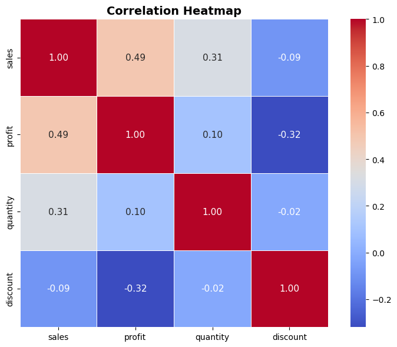

```python
plt.figure(figsize=(8,6))

sns.heatmap(
    correlation_matrix,
    annot=True,
    cmap="coolwarm",
    fmt=".2f",
    linewidths=0.5,
    square=True,
    cbar=True,
    annot_kws={"size":11}
)

plt.title(
    "Correlation Heatmap",
    fontsize=14,
    fontweight="bold"
)

plt.tight_layout()

plt.show()
```

## 🔎 Code Explanation

- `plt.figure(figsize=(8,6))`
  - Creates a figure of size 8 × 6 inches for better visualization.
- `sns.heatmap(correlation_matrix, ...)`
  - Creates a heatmap from the previously calculated correlation matrix.
- `annot=True`
  - Displays the correlation coefficient inside each cell.
- `cmap="coolwarm"`
  - Uses a color gradient where:
    - Warm colors indicate stronger positive correlations.
    - Cool colors indicate negative correlations.
- `fmt=".2f"`
  - Displays correlation values with two decimal places.
- `linewidths=0.5`
  - Adds thin borders between cells to improve readability.
- `square=True`
  - Makes each cell square-shaped for a cleaner appearance.
- `cbar=True`
  - Displays the color scale bar indicating correlation strength.
- `annot_kws={"size":11}`
  - Sets the font size of the displayed correlation values.
- `plt.title()`
  - Adds a descriptive chart title.
- `plt.tight_layout()`
  - Adjusts spacing automatically.
- `plt.show()`
  - Displays the completed heatmap.

## 💡 Why It Matters

Although the correlation matrix provides the exact numerical values, it can be difficult to interpret quickly.

A heatmap transforms those numerical values into colors, allowing analysts and business stakeholders to immediately identify strong positive, weak, and negative relationships. This makes complex relationships much easier to understand and communicate.

## 📈 Key Observations

- The strongest positive relationship exists between **Sales and Profit (0.49)**.
- Sales and Quantity show a moderate positive relationship **(0.31)**.
- Profit and Discount exhibit the strongest negative relationship **(-0.32)**.
- Quantity has only a weak relationship with Profit **(0.10)**.
- Discount has almost no relationship with Quantity **(-0.02)**.
- The heatmap clearly highlights that Discount is the only variable showing a noticeable negative relationship with another key business metric (Profit).

## 🧠 Business Insights

- Increasing sales generally contributes to higher profits, but profitability is also influenced by pricing and discount strategies.
- Excessive discounts negatively affect profitability, making discount management an important business concern.
- Higher purchase quantities do not necessarily translate into significantly higher profits.
- The visual representation confirms that pricing decisions have a greater impact on profit than order quantity alone.

## 💼 Business Recommendation

- Continue driving sales growth while maintaining healthy profit margins.
- Carefully monitor discount strategies to avoid unnecessary reductions in profitability.
- Evaluate promotional campaigns based on both sales growth and profit contribution rather than sales volume alone.
- Incorporate correlation analysis into regular business reporting to monitor relationships among key performance indicators over time.

## ⭐ Key Takeaway

The heatmap visually confirms that **Discount has the strongest negative relationship with Profit**, emphasizing the importance of balancing promotional discounts with overall business profitability.

## ✅ Analysis Summary

The correlation heatmap provides a clear visual summary of the relationships among the numerical variables in the Superstore dataset. It confirms that Sales and Profit are moderately positively correlated, while Discount has the strongest negative relationship with Profit. The visualization reinforces the importance of maintaining an effective balance between sales growth and discount strategies to achieve sustainable profitability.

# ✅ Section Summary (5.10)

The Correlation Analysis section examined the relationships among the key numerical variables: Sales, Profit, Quantity, and Discount.

Using both the correlation matrix and the heatmap, we identified that Sales and Profit share a moderate positive relationship, whereas Discount has the strongest negative relationship with Profit. Quantity shows only weak relationships with the other variables, indicating that increasing the number of items sold does not necessarily improve profitability.

Overall, this analysis demonstrates that pricing and discount decisions have a greater influence on profit than sales volume alone.

# ➡️ Next Analysis

In the next section (**5.11 Time Series Analysis**), we will analyze how business performance changes over time.

Using monthly and yearly trends, we will identify seasonal patterns, sales growth, profit fluctuations, and important business periods that can support forecasting and strategic planning.

# 📊 5.11 Time Series Analysis

## 📖 Business Scenario

Business performance is not only influenced by products, customers, or discounts, but also by time. Sales and profits often fluctuate throughout the year due to seasonal demand, holidays, promotions, and changing customer behavior.

Analyzing sales and profit over time helps businesses identify growth trends, seasonal patterns, and periods of high or low performance. These insights support better forecasting, inventory planning, staffing, and marketing decisions.

## 🎯 Business Questions

1. How do sales change over time?
2. How does profit change over time?
3. Are there any seasonal patterns in business performance?
4. Which months perform the best and worst?
5. Is the business growing consistently over time?

## 🎯 Overall Step Purpose

The objective of this section is to analyze business performance over time by examining monthly sales and profit trends.

This analysis helps identify growth trends, seasonal patterns, and recurring fluctuations that support better forecasting, inventory planning, and strategic decision-making.

## 📊 5.11.1 Monthly Sales Trend

## 🎯 Step Purpose

The objective of this analysis is to examine how total sales change over time on a monthly basis.

By analyzing monthly sales trends, we can identify periods of business growth, seasonal fluctuations, and months with exceptional or weak performance. These insights help businesses improve forecasting, inventory planning, and promotional strategies.

## 📊 Chart Introduction

The following line chart illustrates the monthly sales trend throughout the available time period.

Each point represents the total sales generated during a specific month, allowing us to observe changes in business performance over time.

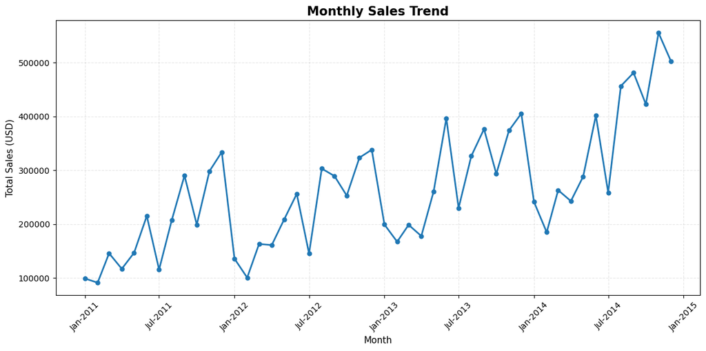

```python
# Create a Year-Month column for monthly analysis
df["year_month"] = df["order_date"].dt.to_period("M")

# Calculate Monthly Sales
monthly_sales = (
    df.groupby("year_month")["sales"]
      .sum()
      .reset_index()
)

# Convert Period to Timestamp for plotting
monthly_sales["year_month"] = (
    monthly_sales["year_month"]
    .dt.to_timestamp()
)

# Plot Monthly Sales Trend
plt.figure(figsize=(12,6))

plt.plot(
    monthly_sales["year_month"],
    monthly_sales["sales"],
    marker="o",
    linewidth=2,
    markersize=5
)

plt.title(
    "Monthly Sales Trend",
    fontsize=15,
    fontweight="bold"
)

plt.xlabel(
    "Month",
    fontsize=11
)

plt.ylabel(
    "Total Sales (USD)",
    fontsize=11
)

# Better date formatting
ax = plt.gca()
ax.xaxis.set_major_locator(mdates.MonthLocator(interval=6))
ax.xaxis.set_major_formatter(mdates.DateFormatter("%b-%Y"))

plt.xticks(rotation=45)

plt.grid(
    linestyle="--",
    alpha=0.3
)

plt.tight_layout()

plt.show()
```

## 🔎 Code Explanation

- `df["year_month"] = df["order_date"].dt.to_period("M")`
  - Extracts the year and month from each order date, allowing transactions within the same month to be grouped together.
- `groupby("year_month")["sales"].sum()`
  - Aggregates the total sales generated during each month.
- `.reset_index()`
  - Converts the grouped output into a structured DataFrame for further processing.
- `.dt.to_timestamp()`
  - Converts the Period datatype into Timestamp so that it can be plotted on a continuous time axis.
- `plt.plot()`
  - Creates a line chart to visualize how monthly sales evolve over time.
- `mdates.MonthLocator(interval=6)`
  - Displays date labels every six months, preventing overcrowding on the x-axis.
- `mdates.DateFormatter("%b-%Y")`
  - Formats dates as **Jan-2011**, **Jul-2011**, etc., making the timeline easier to read.
- `plt.grid()`
  - Adds subtle gridlines to improve comparison between months.
- `plt.tight_layout()`
  - Automatically adjusts spacing for a cleaner presentation.
- `plt.show()`
  - Displays the completed visualization.

## 💡 Why It Matters

Business performance is rarely constant throughout the year. Monthly trend analysis helps organizations understand whether sales are improving, declining, or following seasonal patterns.

These insights support demand forecasting, inventory planning, marketing campaigns, budgeting, and long-term business strategy.

## 📈 Key Observations

- Monthly sales exhibit a clear long-term upward trend from 2011 to 2014.
- Sales fluctuate considerably between months, indicating the presence of seasonal or market-driven variations.
- The highest monthly sales are recorded during the second half of 2014, exceeding **USD 550,000**.
- Early 2011 records the lowest monthly sales, with values close to **USD 90,000**.
- Although temporary declines occur, the overall business trajectory remains consistently positive.
- The business demonstrates stronger and more stable sales performance during the later years of the dataset.

## 🧠 Business Insights

The company has experienced sustained business growth over the four-year period, suggesting successful market expansion and increasing customer demand.

The repeated fluctuations indicate that sales are influenced by recurring seasonal factors, promotional activities, or customer purchasing cycles.

The exceptional performance observed during late 2014 suggests that the company effectively capitalized on high-demand periods, providing valuable opportunities for future planning.

## 💼 Business Recommendation

- Increase inventory levels before historically high-performing months to avoid stock shortages.
- Analyze the promotional strategies and operational practices used during late 2014 and replicate successful initiatives in future years.
- Investigate months with lower sales performance to identify operational challenges or opportunities for targeted marketing campaigns.
- Incorporate monthly sales trends into forecasting models to improve budgeting, staffing, and inventory planning.

## ⭐ Key Takeaway

The Monthly Sales Trend reveals a healthy and steadily growing business. Despite normal month-to-month fluctuations, the company demonstrates consistent long-term growth, with 2014 emerging as the strongest-performing year in the dataset.

## ✅ Analysis Summary

The Monthly Sales Trend analysis indicates that the Superstore business has expanded significantly between 2011 and 2014. While sales fluctuate due to seasonal and market-related factors, the overall upward trajectory confirms sustained business growth. These findings provide valuable insights for forecasting, inventory management, and future strategic planning.

## 📊 5.11.2 Monthly Profit Trend

## 🎯 Step Purpose

The objective of this analysis is to examine how monthly profit changes over time.

While sales indicate business volume, profit reflects the actual financial performance of the company. Analyzing monthly profit trends helps identify periods of high profitability, loss-making months, and the overall financial health of the business. These insights support better pricing strategies, cost control, and long-term financial planning.

## 📊 Chart Introduction

The following line chart illustrates the monthly profit trend throughout the analysis period.

Each point represents the total profit earned during a specific month. By observing the trend over time, we can evaluate whether business growth is accompanied by sustainable profitability and identify months with unusually high or low financial performance.

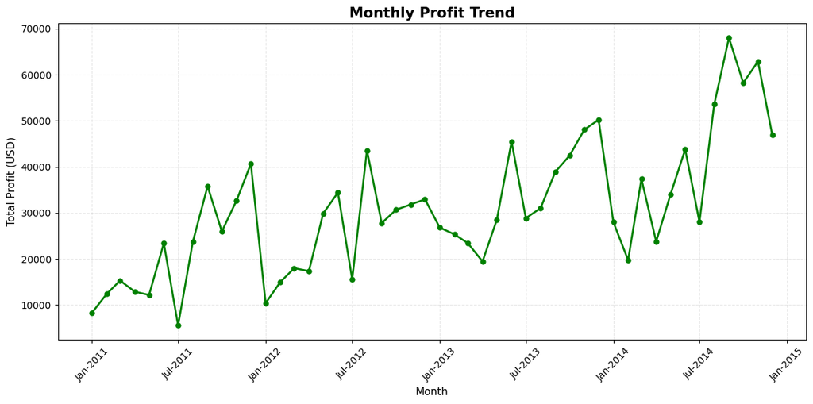

```python
# Calculate Monthly Profit
monthly_profit = (
    df.groupby("year_month")["profit"]
      .sum()
      .reset_index()
)

# Convert Period to Timestamp
monthly_profit["year_month"] = (
    monthly_profit["year_month"]
    .dt.to_timestamp()
)

# Plot Monthly Profit Trend
plt.figure(figsize=(12,6))

plt.plot(
    monthly_profit["year_month"],
    monthly_profit["profit"],
    marker="o",
    linewidth=2,
    markersize=5,
    color="green"
)

plt.title(
    "Monthly Profit Trend",
    fontsize=15,
    fontweight="bold"
)

plt.xlabel(
    "Month",
    fontsize=11
)

plt.ylabel(
    "Total Profit (USD)",
    fontsize=11
)

# Better Date Formatting
ax = plt.gca()

ax.xaxis.set_major_locator(
    mdates.MonthLocator(interval=6)
)

ax.xaxis.set_major_formatter(
    mdates.DateFormatter("%b-%Y")
)

plt.xticks(rotation=45)

plt.grid(
    linestyle="--",
    alpha=0.3
)

plt.tight_layout()

plt.show()
```

## 🔎 Code Explanation

- **Group data by `year_month`**
  - Aggregates the total profit earned in each month.
- **Convert Period to Timestamp**
  - Converts the monthly period into a datetime format for proper plotting.
- **Create the Line Plot**
  - Plots monthly profit values using a green line with circular markers to clearly display month-to-month changes.
- **Customize the Chart**
  - Adds a descriptive title, axis labels, six-month interval date formatting, rotated x-axis labels, and grid lines to improve readability.
- **Optimize Layout**
  - Uses `tight_layout()` to prevent overlapping labels and ensure a clean presentation.

## 💡 Why It Matters

Sales growth alone does not guarantee business success. A company may achieve high sales while earning very little profit due to heavy discounts, high operational costs, or inefficient pricing strategies.

Analyzing monthly profit trends helps determine whether revenue growth is translating into sustainable profitability. It also identifies periods of unusually high or low profit, enabling better financial planning and strategic decision-making.

## 📈 Key Observations

- Profit generally follows an upward trend over the four-year period.
- Early months (2011) generated relatively low monthly profits compared to later years.
- Several months experienced noticeable profit declines despite the overall upward trend.
- Profit reached its highest levels during the second half of 2014, exceeding **$60,000** in multiple months.
- Month-to-month profit fluctuations are much larger than sales fluctuations, indicating that profitability is influenced by factors beyond sales volume.

## 🧠 Business Insights

Although the company is becoming more profitable over time, profit growth is not consistent across all months.

The sharp fluctuations suggest that profitability is heavily affected by factors such as discount policies, product mix, seasonal demand, and operational costs. This indicates that maintaining high sales alone is insufficient; controlling costs and optimizing pricing strategies are equally important for sustainable financial performance.

## 💼 Business Recommendation

- Investigate months with unusually low profits to identify underlying causes.
- Review discount strategies during low-profit periods to ensure profitability is not sacrificed for higher sales.
- Replicate the business strategies, product mix, and promotional campaigns used during the highly profitable months of 2014.
- Develop forecasting models using historical monthly profit trends to support budgeting and resource planning.

## ⭐ Key Takeaway

The business demonstrates a positive long-term profit trend, indicating overall financial growth. However, significant monthly fluctuations highlight the need for better control over pricing, discounts, and operational efficiency to achieve more stable and predictable profitability.

## ✅ Analysis Summary

The Monthly Profit Trend analysis reveals that the company has steadily improved its profitability over the four-year period. While profit generally increased over time, several months exhibited substantial fluctuations, suggesting that external business factors strongly influence financial performance. These findings emphasize the importance of balancing sales growth with effective cost management and pricing strategies.

# ✅ Section Summary (5.11)

The Time Series Analysis provides a comprehensive view of how the Superstore's business performance evolved over time.

The Monthly Sales Trend reveals a consistent upward trajectory from 2011 to 2014, indicating steady business growth and increasing customer demand. Although monthly sales fluctuate due to seasonal and market-related factors, the long-term trend demonstrates successful business expansion.

Similarly, the Monthly Profit Trend shows continuous improvement in profitability over the same period. However, profit fluctuates more significantly than sales, suggesting that profitability is influenced not only by revenue but also by pricing strategies, discount policies, product mix, and operational costs.

Overall, the time series analysis indicates that the business has grown steadily while highlighting the importance of balancing sales growth with sustainable profitability. These insights provide valuable support for forecasting, inventory planning, budgeting, and long-term strategic decision-making.

# 📊 6. Final Business Report

## 📖 Executive Business Scenario

Global Superstore operates across multiple markets, regions, customer segments, product categories, and shipping modes. As the business continues to expand, management seeks to understand the key factors influencing sales performance, profitability, customer purchasing behavior, and operational efficiency.

To support strategic decision-making, an exploratory data analysis (EDA) was conducted on historical sales transactions. The analysis examined business performance from multiple perspectives, including sales trends, profit distribution, discount policies, customer segments, product categories, shipping methods, regional performance, and time-based trends.

The objective of this report is to consolidate the analytical findings into meaningful business insights and provide data-driven recommendations that can support future business growth, improve profitability, and optimize operational performance.

## 🎯 Business Objectives

The primary objectives of this business analysis were to:

1. Evaluate overall sales and profit performance across different business dimensions.
2. Identify the most profitable and least profitable product categories and sub-categories.
3. Understand customer purchasing behavior across different market segments.
4. Analyze the impact of discount policies on business profitability.
5. Evaluate shipping modes and their contribution to sales and profit.
6. Identify relationships among key business variables using correlation analysis.
7. Examine monthly sales and profit trends to understand long-term business growth.
8. Generate actionable business recommendations that can improve profitability, optimize pricing strategies, and support strategic decision-making.

## 🔍 Overall Findings

The exploratory data analysis reveals several important insights into the sales performance, profitability, customer behavior, and operational efficiency of the Global Superstore business.

### 1. Business Performance

- The business demonstrates a strong upward growth trend in both **sales** and **profit** from 2011 to 2014, indicating successful business expansion over time.
- Although sales have consistently increased, profitability exhibits greater month-to-month fluctuations, suggesting that revenue growth alone does not always translate into higher profits.

### 2. Product Performance

- A small number of product categories and sub-categories contribute a significant share of the company's total sales and profit.
- Some sub-categories generate high sales but relatively low profits, indicating potential pricing, discounting, or cost-related challenges.

### 3. Customer Analysis

- The **Consumer** segment contributes the highest share of both sales and profit, making it the company's most valuable customer segment.
- Corporate and Home Office customers also contribute positively, providing opportunities for further business growth through targeted marketing strategies.

### 4. Regional Performance

- Business performance varies across different regions.
- Certain regions consistently outperform others in terms of both sales and profitability, indicating stronger market demand and operational effectiveness.

### 5. Shipping Analysis

- **Standard Class** shipping accounts for the majority of total sales and profit, making it the most preferred shipping method among customers.
- Faster shipping modes contribute comparatively less to overall revenue, suggesting that most customers prioritize cost-effective delivery over speed.

### 6. Discount Analysis

- Discounts show a negative relationship with profitability.
- Higher discounts generally reduce profit, highlighting the importance of maintaining balanced pricing strategies.

### 7. Correlation Analysis

- Sales and profit exhibit a moderate positive relationship, indicating that higher sales generally contribute to higher profits.
- Discount has the strongest negative correlation with profit, reinforcing the findings from the discount analysis.

### 8. Time Series Analysis

- Monthly sales and profit both display long-term positive growth trends.
- Seasonal fluctuations are evident throughout the years, suggesting recurring variations in customer demand and purchasing behavior.
- The business achieves its strongest overall performance during 2014, reflecting continuous improvement throughout the analysis period.

## 💪 Business Strengths

Based on the comprehensive analysis of sales, profit, customer behavior, discounts, shipping methods, and time-series trends, the following key strengths have been identified:

### 1. Strong Long-Term Business Growth

The company demonstrates consistent growth in both sales and profit from 2011 to 2014. This indicates successful market expansion, increasing customer demand, and an overall healthy business trajectory.

### 2. Diverse Customer Base

The business serves multiple customer segments, including Consumer, Corporate, and Home Office customers. This diversified customer portfolio reduces dependency on a single customer group and contributes to stable revenue generation.

### 3. High Revenue from Consumer Segment

The Consumer segment contributes the largest share of total sales and profit, making it the company's strongest and most valuable customer segment.

### 4. Efficient Standard Shipping Operations

Standard Class shipping generates the highest sales and profit among all shipping modes. This suggests that the company's primary logistics strategy effectively balances customer satisfaction and operational efficiency.

### 5. Positive Relationship Between Sales and Profit

The correlation analysis shows a moderate positive relationship between sales and profit, indicating that business growth generally contributes to improved financial performance.

### 6. Consistent Regional Business Performance

Several regions consistently generate strong sales and profits, demonstrating successful market penetration and effective regional business operations.

### 7. Broad Product Portfolio

The company offers products across multiple categories and sub-categories, reducing business risk by diversifying revenue sources and serving a wide range of customer needs.

### 8. Healthy Business Expansion Over Time

The time-series analysis confirms continuous improvement in overall business performance, with 2014 emerging as the strongest-performing year. This reflects effective business strategies and sustained organizational growth.

## ⚠️ Business Challenges

Although the overall business performance is strong, the analysis identifies several challenges that may limit future growth and profitability if not addressed.

### 1. High Discounts Reduce Profitability

The discount analysis and correlation analysis reveal a clear negative relationship between discounts and profit. While discounts may help increase sales volume, excessive discounting significantly reduces overall profitability and affects long-term financial performance.

### 2. Profit Growth is Less Stable than Sales Growth

Although sales have shown consistent growth over time, monthly profit exhibits much larger fluctuations. This indicates that increasing revenue alone does not guarantee higher profitability, and operational efficiency remains an important concern.

### 3. Uneven Product Performance

Not all product categories and sub-categories contribute equally to business success. Some products generate high sales but comparatively low profits, suggesting pricing issues, excessive discounting, or higher operating costs.

### 4. Regional Performance Imbalance

Business performance varies considerably across regions. While some regions consistently generate strong sales and profits, others contribute relatively less, indicating opportunities for market expansion and performance improvement.

### 5. Dependence on a Single Customer Segment

The Consumer segment contributes the largest share of both sales and profit. Although this is currently a strength, excessive dependence on one customer segment may expose the business to future market risks if customer behavior changes.

### 6. Limited Contribution from Premium Shipping Services

Standard Class shipping dominates overall sales and profit, while faster shipping methods contribute comparatively less. This suggests that premium shipping services may be underutilized or not sufficiently attractive to customers.

### 7. Seasonal Business Fluctuations

The time-series analysis reveals recurring monthly fluctuations in both sales and profit. These seasonal variations may create challenges in inventory planning, workforce management, and financial forecasting.

### 8. Opportunity for Better Data-Driven Decision Making

The analysis indicates that business performance is influenced by multiple interconnected factors, including pricing, discounts, customer segments, products, and regions. Integrating these insights into regular decision-making processes could further improve operational efficiency and long-term profitability.

## 💡 Strategic Recommendations

Based on the findings of this analysis, the following strategic recommendations are proposed to improve business performance, increase profitability, and support sustainable long-term growth.

### 1. Optimize Discount Strategy

Implement a data-driven discount policy by reducing excessive discounts on products that consistently generate low profits. Promotional offers should be targeted toward products and customer segments where discounts produce measurable sales growth without significantly reducing profitability.

### 2. Focus on High-Profit Products

Increase marketing efforts, inventory availability, and promotional campaigns for product categories and sub-categories that consistently generate high profits. At the same time, review pricing and cost structures for low-performing products to improve their profitability.

### 3. Strengthen Regional Performance

Identify the business practices used in high-performing regions and replicate them in regions with lower sales and profit. Region-specific marketing campaigns and customer engagement strategies can help reduce performance disparities.

### 4. Expand Corporate and Home Office Segments

Although the Consumer segment contributes the highest revenue, additional growth opportunities exist within the Corporate and Home Office segments. Developing targeted promotions and customized service offerings for these customers can diversify revenue sources and reduce business dependence on a single customer segment.

### 5. Improve Profit Monitoring

Monitor profitability on a monthly basis rather than focusing solely on sales performance. Establish key performance indicators (KPIs) that track both revenue growth and profit margins to support timely business decisions.

### 6. Review Shipping Strategy

Evaluate customer preferences regarding shipping services and identify opportunities to improve the utilization of premium shipping options without increasing operational costs unnecessarily.

### 7. Implement Seasonal Planning

Use historical sales and profit trends to forecast seasonal demand. This can improve inventory planning, workforce allocation, and budgeting while reducing the impact of seasonal fluctuations.

### 8. Institutionalize Data-Driven Decision Making

Integrate regular business analytics into the decision-making process by monitoring sales, profit, discounts, customer behavior, and regional performance through interactive dashboards and periodic performance reviews.

## 🚀 Action Plan

To convert the analytical findings into measurable business improvements, the following phased action plan is recommended.

### 📅 Immediate Actions (0–3 Months)

| **Action** | **Expected Outcome** |
| --- | --- |
| Review and optimize discount policies for low-profit products. | Reduce unnecessary profit losses while maintaining competitive sales. |
| Identify underperforming product categories and sub-categories for detailed business review. | Improve pricing strategies and product profitability. |
| Develop monthly sales and profit dashboards for management monitoring. | Enable faster, data-driven business decisions. |

### 📅 Medium-Term Actions (3–12 Months)

| **Action** | **Expected Outcome** |
| --- | --- |
| Expand targeted marketing campaigns for Corporate and Home Office customer segments. | Diversify revenue sources and reduce dependence on the Consumer segment. |
| Implement region-specific sales improvement strategies based on best-performing regions. | Improve sales performance in underperforming markets. |
| Optimize inventory planning using historical monthly sales trends. | Reduce stock shortages and improve inventory efficiency. |

### 📅 Long-Term Actions (Beyond 12 Months)

| **Action** | **Expected Outcome** |
| --- | --- |
| Develop predictive analytics models for sales and demand forecasting. | Improve business planning and resource allocation. |
| Build interactive business intelligence dashboards using Power BI or Tableau. | Enable continuous business monitoring and executive reporting. |
| Establish a continuous data-driven decision-making framework across departments. | Improve operational efficiency and support sustainable business growth. |

## 📈 Expected Business Impact

If the recommended strategies are successfully implemented, the organization can expect several positive business outcomes that contribute to long-term growth and operational excellence.

### Financial Impact

- Improved profitability by reducing unnecessary discounting on low-margin products.
- Better pricing strategies that balance revenue generation with sustainable profit growth.
- More efficient allocation of business resources toward high-performing products and customer segments.

### Operational Impact

- Improved inventory planning through the use of historical sales trends.
- More effective regional business strategies by replicating best practices from high-performing markets.
- Enhanced monitoring of key business indicators through regular performance dashboards.

### Customer Impact

- Stronger customer engagement across Corporate and Home Office segments.
- Improved customer satisfaction by aligning products, pricing, and shipping strategies with customer preferences.
- Reduced dependence on a single customer segment through diversified marketing initiatives.

### Strategic Impact

- Greater use of data-driven decision making across business functions.
- Improved forecasting capability for future sales and operational planning.
- Stronger competitive positioning through continuous performance monitoring and business optimization.

### Long-Term Business Value

Collectively, these improvements are expected to strengthen the company's financial performance, improve operational efficiency, support sustainable business growth, and establish a stronger foundation for future strategic decision-making.

## 🏆 Final Business Conclusion

The exploratory data analysis of the Global Superstore dataset provides a comprehensive understanding of the company's sales performance, profitability, customer behavior, product performance, regional trends, shipping preferences, discount strategies, and long-term business growth.

The analysis demonstrates that the business has experienced steady growth in both sales and profit from 2011 to 2014, reflecting a strong market position and increasing customer demand. However, it also highlights several opportunities for improvement, particularly in discount management, product profitability, regional performance, and customer diversification.

By implementing the recommended strategies—including optimizing discount policies, strengthening high-performing product categories, expanding business across multiple customer segments, improving regional performance, and adopting data-driven decision-making—the organization can further enhance profitability while maintaining sustainable business growth.

Overall, this project demonstrates how exploratory data analysis can transform raw business data into meaningful business intelligence that supports strategic decision-making. The findings and recommendations presented in this report provide a practical foundation for future business optimization and long-term competitive success.

# 📄 7. Executive Summary

This project presents a comprehensive Exploratory Data Analysis (EDA) of the Global Superstore dataset to evaluate the company's sales performance, profitability, customer behavior, product performance, shipping methods, regional trends, discount strategies, and business growth over time.

The primary objective of the analysis was to transform historical business data into actionable insights that support strategic decision-making. Using Python and its data analysis libraries, the dataset was cleaned, explored, and analyzed through descriptive statistics, business-oriented visualizations, correlation analysis, and time-series analysis.

The analysis revealed that the company experienced consistent growth in both sales and profit between 2011 and 2014, demonstrating strong overall business expansion. The Consumer segment emerged as the company's most valuable customer group, while Standard Class proved to be the most widely used and profitable shipping method. Several product categories and regions consistently generated high sales and profits, highlighting important business strengths.

However, the analysis also identified several challenges. High discount levels were found to negatively impact profitability, profit growth fluctuated more than sales growth, and business performance varied across products and regions. These findings indicate opportunities to optimize pricing strategies, strengthen underperforming markets, and improve operational efficiency.

Based on these insights, several strategic recommendations were proposed, including optimizing discount policies, expanding high-performing customer segments, improving regional performance, strengthening inventory planning, implementing predictive analytics, and promoting data-driven decision-making across the organization.

Overall, this project demonstrates how exploratory data analysis can convert raw transactional data into meaningful business intelligence. The findings provide practical recommendations that can help improve profitability, operational performance, and long-term strategic planning while illustrating the value of data analytics in modern business decision-making.

# 🏁 8. Project Conclusion

This project successfully demonstrates the complete workflow of an Exploratory Data Analysis (EDA) project using the Global Superstore dataset. Starting from raw business data, the dataset was cleaned, explored, analyzed, and transformed into meaningful business insights through statistical analysis and data visualization.

Throughout the project, various aspects of business performance were examined, including sales trends, profitability, customer segments, product categories, regional performance, shipping methods, discount strategies, correlation among business variables, and time-series patterns. Each analysis was supported by appropriate visualizations and interpreted from a business perspective to provide practical and actionable insights.

The findings indicate that while the company has achieved consistent growth in sales and profit over the years, there remain opportunities to improve profitability by optimizing discount strategies, strengthening underperforming regions, enhancing product-level decision-making, and diversifying customer segments. The recommendations proposed in this project provide a structured roadmap for improving operational efficiency and supporting long-term business growth.

From a technical perspective, this project demonstrates the effective use of Python for data analysis by applying data cleaning techniques, exploratory data analysis, statistical summaries, correlation analysis, and professional data visualization using libraries such as Pandas, NumPy, Matplotlib, and Seaborn.

Overall, this project demonstrates the practical application of data analytics in solving real-world business problems. It illustrates how historical business data can be transformed into valuable insights that help organizations identify opportunities, solve business problems, and make informed strategic decisions. The knowledge and techniques applied in this project provide a strong foundation for more advanced analytical tasks such as predictive modeling, business intelligence dashboards, and machine learning applications.

# ⚠️ 9. Project Limitations

Although this project provides valuable business insights through exploratory data analysis, it is subject to certain limitations due to the nature of the available dataset and the scope of the analysis.

### 1. Historical Data Analysis

The analysis is based entirely on historical transaction data from the Global Superstore dataset. Business conditions, customer preferences, and market dynamics may have changed over time, limiting the direct applicability of these findings to current business scenarios.

### 2. Limited Business Variables

The dataset primarily contains transactional information such as sales, profit, discounts, customer segments, products, and regions. Important business factors including customer demographics, marketing campaigns, competitor activities, supplier costs, and customer satisfaction were not available for analysis.

### 3. No Predictive Modeling

This project focuses on Exploratory Data Analysis (EDA) to understand historical business performance. Advanced predictive techniques such as sales forecasting, customer churn prediction, demand forecasting, or machine learning models were beyond the scope of this analysis.

### 4. Correlation Does Not Imply Causation

The correlation analysis identifies statistical relationships between variables but does not establish cause-and-effect relationships. Additional statistical testing or experimental analysis would be required to determine causal factors influencing business performance.

### 5. Business Recommendations are Data-Driven

The recommendations presented in this report are derived solely from patterns observed within the available dataset. Real-world business decisions should also consider external market conditions, organizational objectives, financial constraints, and managerial expertise before implementation.

# 🚀 10. Future Improvements

This project provides a strong foundation for business analytics through Exploratory Data Analysis (EDA). However, several advanced analytical techniques and business intelligence solutions can be incorporated in future work to generate even deeper insights and improve organizational decision-making.

### 1. Interactive Business Dashboard

Develop an interactive dashboard using **Power BI** or **Tableau** to enable real-time monitoring of key business metrics such as sales, profit, regional performance, customer segments, and product categories. Interactive dashboards would allow management to explore business performance more efficiently.

### 2. Sales Forecasting

Implement time-series forecasting models such as **ARIMA**, **Prophet**, or **LSTM Neural Networks** to predict future sales and support inventory planning, budgeting, and resource allocation.

### 3. Customer Segmentation

Apply clustering techniques such as **K-Means Clustering** to group customers based on purchasing behavior. This would enable personalized marketing campaigns and improve customer relationship management.

### 4. Customer Lifetime Value (CLV) Analysis

Estimate Customer Lifetime Value to identify high-value customers and develop long-term customer retention strategies that maximize business profitability.

### 5. Market Basket Analysis

Perform association rule mining using algorithms such as **Apriori** or **FP-Growth** to identify products that are frequently purchased together. These insights can support cross-selling, product bundling, and promotional strategies.

### 6. Profit Prediction Model

Develop machine learning models to predict product profitability based on variables such as sales, discounts, shipping costs, customer segments, and regional characteristics. Such models could assist management in making proactive business decisions.

### 7. Advanced Statistical Analysis

Incorporate hypothesis testing, regression analysis, ANOVA, and other statistical techniques to validate business assumptions and investigate causal relationships among variables.

### 8. Integration of External Business Data

Future studies could combine transactional data with external information such as economic indicators, marketing campaigns, customer demographics, seasonal events, and competitor analysis to provide a more comprehensive understanding of business performance.

### 9. Automated Reporting System

Develop an automated reporting pipeline using Python to generate periodic business reports and update dashboards automatically, reducing manual effort and improving reporting efficiency.

## 🌟 Overall Future Scope

This project establishes a strong foundation for business analytics by demonstrating how exploratory data analysis (EDA) can transform raw transactional data into meaningful business insights.

By integrating advanced statistical techniques, machine learning models, business intelligence platforms, predictive analytics, and automated reporting systems, this project can evolve from an exploratory analysis into a comprehensive decision-support system. Such a system would enable organizations to make predictive, data-driven, and strategically informed business decisions while continuously monitoring and optimizing overall business performance.